# Exam 1

## Exam 1

#### Question

1. A [random procedure](https://en.wikipedia.org/wiki/Random_number_generation) generated the following sample (sequence of measurements):

   $$\mathbf{x} = 50, 57, 58, 51, 51, 59, 58, 59, 51, 56$$

   You can download the data as a CSV file (for importing into a spreadsheet or R): list_counting_basic_data_92422.csv
   1. How many of the measurements are less than 56? In other words, determine $\#[\mathbf{x}<56]$.
   2. How many of the measurements are less than or equal to 51? In other words, determine $\#[\mathbf{x}\le51]$.
   3. How many of the measurements are greater than 59? In other words, determine $\#[\mathbf{x}>59]$.
   4. How many of the measurements are greater than or equal to 50? In other words, determine $\#[\mathbf{x}\ge50]$.
   5. If 1 of the measurements are less than $x_{\text{c}}$, and $x_{\text{c}}$ is a measurement from sample $\mathbf{x}$, then what is $x_{\text{c}}$? In other words, determine a measurement $x_{\text{c}}$ from sequence $\mathbf{x}$ such that $\#[\mathbf{x}<x_{\text{c}}] = 1$.
   6. If 6 of the measurements are less than or equal to $x_{\text{c}}$, and $x_{\text{c}}$ is a measurement from sample $\mathbf{x}$, then what is $x_{\text{c}}$? In other words, determine a measurement $x_{\text{c}}$ from sequence $\mathbf{x}$ such that $\#[\mathbf{x}\le x_{\text{c}}] = 6$.
   7. If 2 of the measurements are greater than $x_{\text{c}}$, and $x_{\text{c}}$ is a measurement from sample $\mathbf{x}$, then what is $x_{\text{c}}$? In other words, determine a measurement $x_{\text{c}}$ from sequence $\mathbf{x}$ such that $\#[\mathbf{x}>x_{\text{c}}] = 2$.
   8. If 4 of the measurements are greater than or equal to $x_{\text{c}}$, and $x_{\text{c}}$ is a measurement from sample $\mathbf{x}$, then what is $x_{\text{c}}$? In other words, determine a measurement $x_{\text{c}}$ from sequence $\mathbf{x}$ such that $\#[\mathbf{x}\ge x_{\text{c}}] = 4$.

#### Question

   You can download the data as a CSV file (for importing into a spreadsheet or R): list_counting_between_data_64523.csv
   1. How many of the measurements are inside 20.5 to 26.5? In other words, determine $\#[\mathbf{x}>20.5\texttt{ AND } \mathbf{x}<26.5]$. In other words, determine $\#[20.5<\mathbf{x}<26.5]$.
   2. How many of the measurements are outside 23.5 to 28.5? In other words, determine $\#[\mathbf{x}<23.5\texttt{ OR } \mathbf{x}>28.5]$. In other words, determine $\#[\texttt{NOT}(23.5<\mathbf{x}<28.5)]$.
   3. How many of the measurements are closer than 2 units from 22.5? In other words, determine $\#\left[\big|\mathbf{x}-22.5\big|<2\right]$.
   4. How many of the measurements are farther than 1.5 units from 28? In other words, determine $\#\left[\big|\mathbf{x}-28\big|>1.5\right]$.
   5. Determine a half-integer radius $r$ of an interval with center 23 such that $\#\left[\big|\mathbf{x}-23\big|<r\right] ~=~ 1$.
   6. Determine an integer radius $r$ of an interval with center 26.5 such that $\#\left[\big|\mathbf{x}-26.5\big|>r\right] ~=~ 4$.

#### Question

3. A random procedure generated many measurements: list_counting_large_data_80983.csv

   ```
   51.94, 51.97, 52.04, 50.64, 57.32, 58.67, 50.92, 58.9, 56.81, 56.44, 51.99, 52.43, 51.49, 53.19, 51.15, 59.5, 55.58, 51.9, 52.56, 54.75, 51.33, 56.55, 53.7, 53.22, 52.44, 52.52, 51.28, 56.02, 53.15, 54.86, 58.18, 50.58, 55.11, 53.01, 51.81, 56.05, 56.19, 52.59, 55.53, 55.89, 53.59, 50.79, 52.17, 52.52, 59.18, 54.09, 50.71, 58.73, 51.7, 50.63, 59.5, 55.11, 51.24, 55.48, 59.13, 53.15, 52.19, 55.39, 50.13, 57.45, 56.39, 57.42, 57.53, 59.61, 57.6, 57.89, 53.85, 55.16, 59.97, 54.53, 58.73, 58.25, 59.12, 59.36, 52.54, 52.11, 55.36, 54.33, 50.92, 52.52, 51.62, 51.52, 54.56, 50.76, 52.99, 53.52, 50.76, 59.99, 53.29, 59.25, 50.8, 53.69, 50.3, 55, 56.88, 51.45, 55.34, 57.45, 59.17, 58.17, 56.76, 55.17, 53.96, 52.15, 56.48, 53.95, 52.74, 50.83, 50.48, 57.19, 51.06, 55.58, 55.15, 50.17, 57.17, 56.01, 54.12, 57.79, 53.23, 52.47, 52.39, 57.12, 52.95, 55.31, 54.79, 57.55, 56.39, 51.55, 59.47, 50.82, 58.19, 59.4, 51.92, 59.18, 54.99, 59.94, 55.5, 58.72, 57.97, 52.26, 58.82, 56.7, 50.59, 50.78, 57.86, 55.18, 56.93, 56.84, 52.4, 56.51, 54.46, 50.79, 53.84, 54.69, 57.5, 50.33, 55.4, 54.9, 55.65, 53.88, 55.3, 54.11, 57.63, 54.19, 57.74, 50.04, 57.13, 50.27, 51.63, 54.32, 56.36, 57.35, 55.11, 58.8, 58.19
   ```

   1. How many measurements are in the sample? In other words, determine $\#[\mathbf{x}]$. In the future, we will use $n$ to denote the number of measurements in the sample.
   2. How many of the measurements are less than 57? In other words, determine $\#[\mathbf{x}<57]$.
   3. How many of the measurements are greater than 55.5? In other words, determine $\#[\mathbf{x}>55.5]$.
   4. How many of the measurements are closer than 3 units from 57? In other words, determine $\#\left[\big|\mathbf{x}-57\big|<3\right]$.
   5. How many of the measurements are farther than 1.5 units from 56.2? In other words, determine $\#\left[\big|\mathbf{x}-56.2\big|>1.5\right]$.

#### Question

4. A random procedure generated many measurements: download data

   Please complete the [frequency distribution](https://en.wikipedia.org/wiki/Frequency_distribution) using breaks 70, 75, 80, 85, 90:

   | Interval | Frequency |
   | --- | --- |
   | 70 to 75 |  |
   | 75 to 80 |  |
   | 80 to 85 |  |
   | 85 to 90 |  |

#### Question

5. A random procedure generated 75 measurements, which were organized into the frequency distribution shown below. You can assume the measurements are of a [continuous random variable](https://en.wikipedia.org/wiki/Continuous_or_discrete_variable), such that every measurement is in one of the intervals (and not on a break).

   | interval | frequency |
   | --- | --- |
   | 55 to 60 | 7 |
   | 60 to 65 | 13 |
   | 65 to 70 | 21 |
   | 70 to 75 | 12 |
   | 75 to 80 | 12 |
   | 80 to 85 | 10 |

   1. Evaluate $\#[\mathbf{x}<80]$.
   2. Evaluate $\#[\mathbf{x}>60]$.
   3. Evaluate $\#[|\mathbf{x}-72.5|<7.5]$.
   4. Evaluate $\#[|\mathbf{x}-67.5|>7.5]$.
   5. Evaluate boundary $b$ such that $\#[\mathbf{x}<b] = 65$.
   6. Evaluate boundary $b$ such that $\#[\mathbf{x}>b] = 22$.
   7. Evaluate radius $r$ such that $\#[|\mathbf{x}-70|<r] = 58$.
   8. Evaluate radius $r$ such that $\#[|\mathbf{x}-67.5|>r] = 29$.

#### Question

6. A random procedure generated 70 measurements, which were organized into the [histogram](https://en.wikipedia.org/wiki/Histogram) shown below. You can assume the measurements are of a [continuous variable](https://en.wikipedia.org/wiki/Continuous_or_discrete_variable), such that every measurement is in one of the intervals (and not on a break).

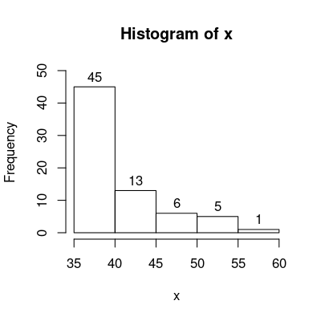

   1. Evaluate $\#[\mathbf{x}<50]$.
   2. Evaluate $\#[\mathbf{x}>50]$.
   3. Evaluate $\#[|\mathbf{x}-45|<5]$.
   4. Evaluate $\#[|\mathbf{x}-50|>5]$.
   5. Evaluate boundary $b$ such that $\#[\mathbf{x}<b] = 58$.
   6. Evaluate boundary $b$ such that $\#[\mathbf{x}>b] = 12$.
   7. Evaluate radius $r$ such that $\#[|\mathbf{x}-47.5|<r] = 24$.
   8. Evaluate radius $r$ such that $\#[|\mathbf{x}-52.5|>r] = 65$.

#### Question

7. A standard twelve-sided [die](https://en.wikipedia.org/wiki/Dice) was rolled 80 times, and the results were organized into the [histogram](https://en.wikipedia.org/wiki/Histogram) shown below. In [dice notation](https://en.wikipedia.org/wiki/Dice_notation), we could say the results of 80d12 were plotted as a histogram. (Pedantic sidenote: it is common to interpret 80d12 as the SUM of 80 rolls, but we will interpret 80d12 as the LIST of 80 rolls and use $\sum 80\text{d}12$ as the sum of 80 rolls.)

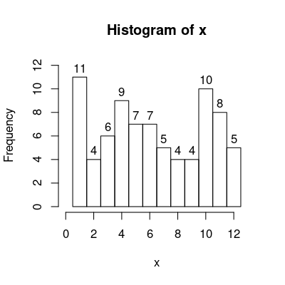

   1. Evaluate $\#[\mathbf{x}<9.5]$.
   2. Evaluate $\#[\mathbf{x}>7.5]$.
   3. Evaluate $\#[|\mathbf{x}-2|<0.5]$.
   4. Evaluate $\#[|\mathbf{x}-5|>3.5]$.
   5. Evaluate half-integer boundary $b$ such that $\#[\mathbf{x}<b] = 37$.
   6. Evaluate half-integer boundary $b$ such that $\#[\mathbf{x}>b] = 31$.
   7. Evaluate half-integer radius $r$ such that $\#[|\mathbf{x}-3|<r] = 6$.
   8. Evaluate half-integer radius $r$ such that $\#[|\mathbf{x}-5|>r] = 46$.

#### Question

8. A standard eight-sided [die](https://en.wikipedia.org/wiki/Dice) was rolled 100 times, and the results were organized into the [pie chart](https://en.wikipedia.org/wiki/Pie_chart) shown below.

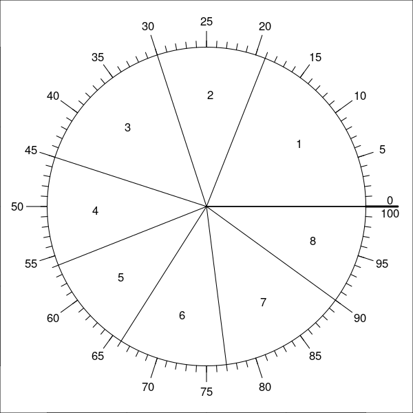

   1. Evaluate $\#[\mathbf{x}<3.5]$.
   2. Evaluate $\#[\mathbf{x}>5.5]$.
   3. Evaluate $\#[|\mathbf{x}-4|<0.5]$.
   4. Evaluate $\#[|\mathbf{x}-3.5|>2]$.
   5. Evaluate half-integer boundary $b$ such that $\#[\mathbf{x}<b] = 56$.
   6. Evaluate half-integer boundary $b$ such that $\#[\mathbf{x}>b] = 23$.
   7. Evaluate half-integer radius $r$ such that $\#[|\mathbf{x}-3|<r] = 37$.
   8. Evaluate integer radius $r$ such that $\#[|\mathbf{x}-6.5|>r] = 76$.

#### Question

9. A [random procedure](https://en.wikipedia.org/wiki/Random_number_generation) generated the following sample (sequence of measurements):

   $$\mathbf{x} = 14, 19, 10, 16, 17, 10, 12, 10, 19, 17$$

   You can download the data as a CSV file (for importing into a spreadsheet or R): list_counting_basic_data_41468.csv
   1. What proportion of the measurements are less than 10? In other words, determine $\text{prop}[\mathbf{x}<10]$.
   2. What proportion of the measurements are less than or equal to 19? In other words, determine $\text{prop}[\mathbf{x}\le19]$.
   3. What proportion of the measurements are greater than 10? In other words, determine $\text{prop}[\mathbf{x}>10]$.
   4. What proportion of the measurements are greater than or equal to 17? In other words, determine $\text{prop}[\mathbf{x}\ge17]$.
   5. If the proportion of measurements less than $x_{\text{c}}$ is 0.6, and $x_{\text{c}}$ is a measurement from sample $\mathbf{x}$, then what is $x_{\text{c}}$? In other words, determine a measurement $x_{\text{c}}$ from sequence $\mathbf{x}$ such that $\text{prop}[\mathbf{x}<x_{\text{c}}] = 0.6$.
   6. If the proportion of measurements less than or equal to $x_{\text{c}}$ is 0.5, and $x_{\text{c}}$ is a measurement from sample $\mathbf{x}$, then what is $x_{\text{c}}$? In other words, determine a measurement $x_{\text{c}}$ from sequence $\mathbf{x}$ such that $\text{prop}[\mathbf{x}\le x_{\text{c}}] = 0.5$.
   7. If the proportion of measurements greater than $x_{\text{c}}$ is 0, and $x_{\text{c}}$ is a measurement from sample $\mathbf{x}$, then what is $x_{\text{c}}$? In other words, determine a measurement $x_{\text{c}}$ from sequence $\mathbf{x}$ such that $\text{prop}[\mathbf{x}>x_{\text{c}}] = 0$.
   8. If the proportion of measurements greater than or equal to $x_{\text{c}}$ is 0.5, and $x_{\text{c}}$ is a measurement from sample $\mathbf{x}$, then what is $x_{\text{c}}$? In other words, determine a measurement $x_{\text{c}}$ from sequence $\mathbf{x}$ such that $\text{prop}[\mathbf{x}\ge x_{\text{c}}] = 0.5$.

#### Question

10. The lengths (in centimeters) of 10 lizards were recorded.

    $$\mathbf{x} = 97, 98, 94, 93, 98, 96, 99, 92, 95, 99$$

    You can download the data as a CSV file (for importing into a spreadsheet or R): lizard_data.csv
    1. What proportion of the measurements are inside 92.5 cm to 98.5 cm? In other words, determine $\text{prop}[\mathbf{x}>92.5\texttt{ AND } \mathbf{x}<98.5]$. In other words, determine $\text{prop}[92.5<\mathbf{x}<98.5]$.
    2. What proportion of the measurements are outside 95.5 cm to 99.5 cm? In other words, determine $\text{prop}[\mathbf{x}<95.5\texttt{ OR } \mathbf{x}>99.5]$. In other words, determine $\text{prop}[\texttt{NOT}(95.5<\mathbf{x}<99.5)]$.
    3. What proportion of the measurements are closer than 3.5 cm from 95 cm? In other words, determine $\text{prop}\left[\big|\mathbf{x}-95\big|<3.5\right]$.
    4. What proportion of the measurements are farther than 1 cm from 94.5 cm? In other words, determine $\text{prop}\left[\big|\mathbf{x}-94.5\big|>1\right]$.
    5. Determine a half-integer radius $r$ of an interval with center 97 cm such that $\text{prop}\left[\big|\mathbf{x}-97\big|<r\right] ~=~ 0.4$.
    6. Determine an integer radius $r$ of an interval with center 97.5 cm such that $\text{prop}\left[\big|\mathbf{x}-97.5\big|>r\right] ~=~ 0.7$.

#### Question

11. Jordan is practicing [free throws](https://en.wikipedia.org/wiki/Free_throw). They has recorded the results of many free throws.

    ```
    ## Hit Hit Hit Miss Hit Hit Hit Hit Hit Hit Hit Miss Miss Hit Hit Hit Hit Hit Hit Hit Hit Hit Hit Hit Hit Hit Hit Hit Hit Miss Hit Hit Hit Hit Hit Hit Hit Hit Hit Hit Hit Hit Miss Hit Miss Hit Hit Hit Hit Miss Hit Hit Hit Hit Hit Hit Hit Hit Hit Hit Hit Miss Hit Hit Hit Hit Hit Hit Hit Miss Hit Hit …
    ```

    You can download the data as a csv: basketball_proportion.csv. The header and first four rows are shown below.

    | i | hit_or_miss |
    | --- | --- |
    | 1 | Hit |
    | 2 | Hit |
    | 3 | Hit |
    | 4 | Miss |
    | $\vdots$ | $\vdots$ |

    1. How many shots did Jordan attempt? (Evaluate $n$.)
    2. How many shots were successful? (Evaluate $n_\text{s}$.)
    3. How many shots were failures? (Evaluate $n_\text{f}$.)
    4. What proportion of Jordan’s shots were successful? (Evaluate $\hat{p}$.)
    5. What proportion of Jordan’s shots were failures? (Evaluate $\hat{q}$.)

#### Question

12. A random procedure generated $n=130$ measurements: download data

    I’ve already determined the frequencies. Please determine the relative frequencies and the densities. A brief description of relative frequency and density can be found [here](https://en.wikipedia.org/wiki/Histogram).

    | Interval | Frequency | Relative Frequency | Density |
    | --- | --- | --- | --- |
    | 30 to 32 | 4 |  |  |
    | 32 to 34 | 5 |  |  |
    | 34 to 36 | 9 |  |  |
    | 36 to 38 | 43 |  |  |
    | 38 to 40 | 69 |  |  |

#### Question

13. A random procedure generated 120 measurements, which were organized into the frequency distribution shown below. You can assume the measurements are of a [continuous random variable](https://en.wikipedia.org/wiki/Continuous_or_discrete_variable), such that every measurement is in one of the intervals (and not on a break).

    | interval | frequency | relative frequency | density |
    | --- | --- | --- | --- |
    | 60 to 65 | 51 | 0.425 | 0.085 |
    | 65 to 70 | 10 | 0.08333 | 0.01667 |
    | 70 to 75 | 5 | 0.04167 | 0.008333 |
    | 75 to 80 | 3 | 0.025 | 0.005 |
    | 80 to 85 | 13 | 0.1083 | 0.02167 |
    | 85 to 90 | 38 | 0.3167 | 0.06333 |

    1. Evaluate $\text{prop}[\mathbf{x}<70]$.
    2. Evaluate $\text{prop}[\mathbf{x}>65]$.
    3. Evaluate $\text{prop}[|\mathbf{x}-75|<5]$.
    4. Evaluate $\text{prop}[|\mathbf{x}-80|>5]$.
    5. Evaluate boundary $b$ such that $\text{prop}[\mathbf{x}<b] = 0.6833$.
    6. Evaluate boundary $b$ such that $\text{prop}[\mathbf{x}>b] = 0.575$.
    7. Evaluate radius $r$ such that $\text{prop}[|\mathbf{x}-72.5|<r] = 0.15$.
    8. Evaluate radius $r$ such that $\text{prop}[|\mathbf{x}-67.5|>r] = 0.9167$.

#### Question

14. A random procedure generated 50 measurements, which were organized into the [histogram](https://en.wikipedia.org/wiki/Histogram) shown below. You can assume the measurements are of a [continuous variable](https://en.wikipedia.org/wiki/Continuous_or_discrete_variable), such that every measurement is in one of the intervals (and not on a break).

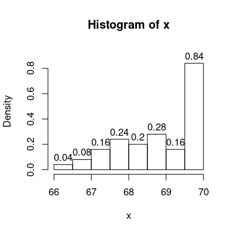

    1. Evaluate $\text{prop}[\mathbf{x}<68]$.
    2. Evaluate $\text{prop}[\mathbf{x}>67]$.
    3. Evaluate $\text{prop}[|\mathbf{x}-67.75|<0.75]$.
    4. Evaluate $\text{prop}[|\mathbf{x}-68.25|>1.25]$.
    5. Evaluate boundary $b$ such that $\text{prop}[\mathbf{x}<b] = 0.06$.
    6. Evaluate boundary $b$ such that $\text{prop}[\mathbf{x}>b] = 0.74$.
    7. Evaluate radius $r$ such that $\text{prop}[|\mathbf{x}-67.25|<r] = 0.08$.
    8. Evaluate radius $r$ such that $\text{prop}[|\mathbf{x}-67|>r] = 0.88$.

#### Question

15. A standard eight-sided [die](https://en.wikipedia.org/wiki/Dice) was rolled 200 times, and the results were organized into the [histogram](https://en.wikipedia.org/wiki/Histogram) shown below. In [dice notation](https://en.wikipedia.org/wiki/Dice_notation), we could say the results of 200d8 were plotted as a histogram. (Pedantic sidenote: it is common to interpret 200d8 as the SUM of 200 rolls, but we will interpret 200d8 as the LIST of 200 rolls and use $\sum 200\text{d}8$ as the sum of 200 rolls.)

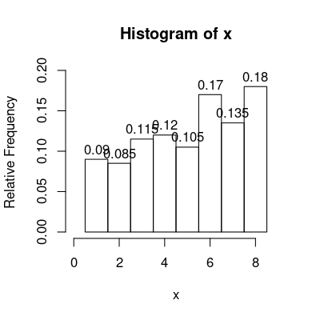

    1. Evaluate $\text{prop}[\mathbf{x}<4.5]$.
    2. Evaluate $\text{prop}[\mathbf{x}>3.5]$.
    3. Evaluate $\text{prop}[|\mathbf{x}-7|<0.5]$.
    4. Evaluate $\text{prop}[|\mathbf{x}-2|>0.5]$.
    5. Evaluate half-integer boundary $b$ such that $\text{prop}[\mathbf{x}<b] = 0.29$.
    6. Evaluate half-integer boundary $b$ such that $\text{prop}[\mathbf{x}>b] = 0.825$.
    7. Evaluate half-integer radius $r$ such that $\text{prop}[|\mathbf{x}-6|<r] = 0.41$.
    8. Evaluate integer radius $r$ such that $\text{prop}[|\mathbf{x}-4.5|>r] = 0.49$.

#### Question

16. A standard six-sided [die](https://en.wikipedia.org/wiki/Dice) was rolled 100 times, and the results were organized into the [pie chart](https://en.wikipedia.org/wiki/Pie_chart) shown below. The outside of the circle marks the cumulative proportion.

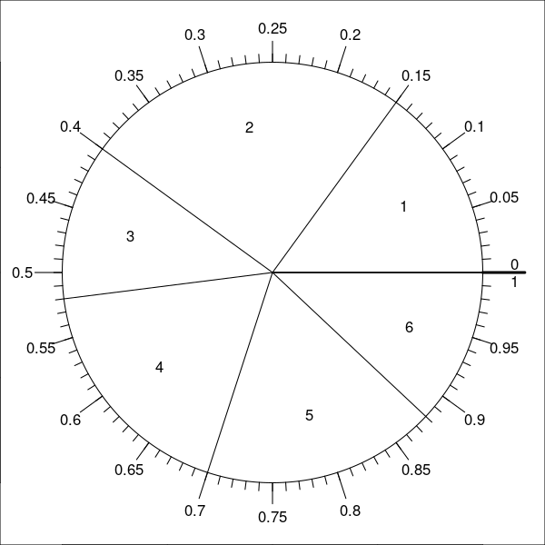

    1. Evaluate $\text{prop}[\mathbf{x}<5.5]$.
    2. Evaluate $\text{prop}[\mathbf{x}>3.5]$.
    3. Evaluate $\text{prop}[|\mathbf{x}-2.5|<1]$.
    4. Evaluate $\text{prop}[|\mathbf{x}-2.5|>1]$.
    5. Evaluate half-integer boundary $b$ such that $\text{prop}[\mathbf{x}<b] = 0.4$.
    6. Evaluate half-integer boundary $b$ such that $\text{prop}[\mathbf{x}>b] = 0.6$.
    7. Evaluate integer radius $r$ such that $\text{prop}[|\mathbf{x}-4.5|<r] = 0.36$.
    8. Evaluate integer radius $r$ such that $\text{prop}[|\mathbf{x}-3.5|>r] = 0.7$.

#### Question

17. Match the five histograms with their appropriate description.

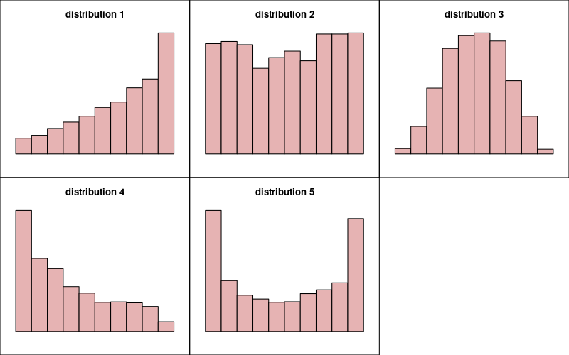

    1. Uniform (Enter an integer between 1 and 5)
    2. Bell (Enter an integer between 1 and 5)
    3. Bimodal (Enter an integer between 1 and 5)
    4. Right-skew (Enter an integer between 1 and 5)
    5. Left-skew (Enter an integer between 1 and 5)

#### Question

18. A sample of size $n=200$ was taken from an unknown population.

    ```
     4.08, 1.04, 1.72, 2.40, 9.14, 9.41, 1.14, 0.01, 9.07, 0.45,
     7.26, 0.30, 9.74, 0.37, 4.29, 1.08, 1.57, 6.62, 7.01, 7.00,
     1.22, 3.20, 0.27, 8.65, 6.00, 3.37, 9.94, 9.16, 9.98, 9.45,
     7.44, 1.42, 7.74, 1.65, 5.59, 0.80, 2.92, 7.38, 1.03, 9.85,
     5.09, 0.00, 3.83, 7.92, 0.80, 9.90, 9.38, 0.91, 0.26, 9.19,
     5.98, 7.95, 7.94, 9.69, 0.19, 4.04, 2.78, 9.51, 8.92, 1.74,
     9.50, 4.46, 0.54, 4.83, 0.71, 9.91, 2.69, 2.73, 5.21, 0.19,
     9.80, 3.59, 0.38, 7.36, 3.52, 5.03, 3.58, 2.74, 9.99, 4.77,
     3.30, 0.31, 2.16, 9.32, 3.06, 7.30, 1.58, 6.27, 3.40, 9.20,
     8.85, 5.92, 0.07, 2.94, 1.15, 8.53, 0.86, 2.40, 0.30, 7.94,
     0.02, 6.92, 0.39, 0.00, 8.74, 9.99, 0.54, 2.76, 0.75, 5.10,
     2.66, 0.00, 8.68, 9.95, 0.00, 2.08, 6.74,10.00, 3.42, 5.92,
     4.67, 0.65, 9.24, 9.18, 1.95, 5.18, 9.23, 8.16, 9.97, 4.84,
     4.24, 0.00, 9.98, 6.62, 5.97, 4.89, 8.76, 1.10, 9.25, 1.34,
     0.97, 0.92, 0.33, 5.43, 7.03, 3.93, 4.58, 7.51, 9.81, 9.28,
     9.52, 7.48, 2.42, 9.85, 3.40, 2.44, 3.18, 0.59, 6.57, 0.80,
     3.54, 3.07, 9.78, 4.58, 4.21, 9.65, 1.72, 6.36,10.00, 9.41,
     7.72, 8.80, 1.44, 7.51, 0.96, 5.66, 9.92, 7.80, 4.88, 1.48,
     7.26, 6.45, 7.27, 7.63, 0.30, 0.38, 7.11, 7.60, 6.08, 4.99,
     1.22, 9.18, 0.37, 7.43, 9.92, 8.78, 9.92, 1.08, 9.97,10.00
    ```

    You can download the data as a CSV. Determine which histogram visualizes the data, and describe the shape of the data.

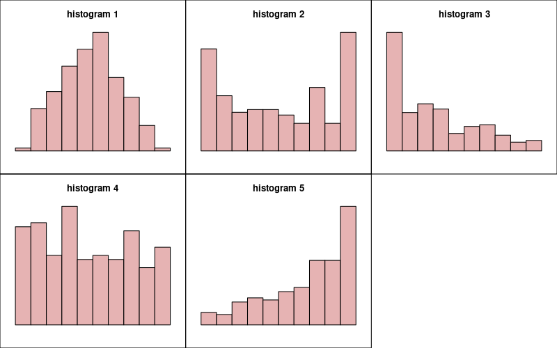

    - Which histogram is appropriate? distribution 1 / distribution 2 / distribution 3 / distribution 4 / distribution 5
    - Which shape description is appropriate? Bell / Uniform / Bimodal / Right-skew / Left-skew

#### Question

19. A sample was gathered.

    $$\mathbf{x} = 42.36, 30.23, 30.4, 31.81, 36.92, 32.16, 36.63, 30.57, 31.58, 32.83, 37.21, 40.49, 30.1$$

    You can download the data as a CSV file.

    Determine $\bar{x}$, the [sample mean](https://en.wikipedia.org/wiki/Mean). Your answer can be rounded to the nearest tenth.

#### Question

20. A sample was gathered.

    $$\mathbf{x} = 30.07, 33.17, 33.51, 48.59, 30.05, 34.38, 32.6, 40.89, 43.32, 33.18, 33.74, 31.1, 37.99$$

    You can download the data as a CSV file.

    Determine the sample [median](https://en.wikipedia.org/wiki/Median). Please enter an exact answer.

#### Question

21. Depending on the type of distribution, we can make a strong claim regarding the mean and median.
    - Symmetric (bell, uniform, bimodal)
      - $\text{mean} \approx \text{median}$
    - Skew-right
      - $\text{mean} > \text{median}$
    - Skew-left
      - $\text{mean} < \text{median}$

    A sample was gathered and visualized with a histogram.

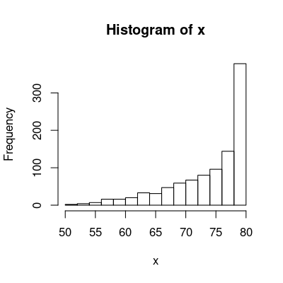

    What claim can you make regarding the mean and median?
    1. $\text{mean} \approx \text{median}$
    2. $\text{mean} > \text{median}$
    3. $\text{mean} < \text{median}$

#### Question

22. A sample was gathered (from a [Bernoulli random variable](https://en.wikipedia.org/wiki/Bernoulli_distribution)).

    $$\mathbf{x} = 0, 0, 0, 0, 1, 1, 0, 1, 0, 1, 0, 0$$

    You can download the data as a CSV file.

    Determine $\bar{x}$, the [sample mean](https://en.wikipedia.org/wiki/Mean). Actually, in this special case of 0s and 1s, the sample mean is called the sample proportion ($\hat{p}$=“p hat”).
    $$\text{when data is 0s and 1s... }$$
    $$\bar{x}=\hat{p}$$
    So, determine the sample proportion. Your answer can be rounded to the nearest hundredth.

#### Question

23. A sample was gathered.

    $$\mathbf{x} = 34.97, 34.99, 32.15, 29.31, 34.97, 33.07, 33.37, 29.89, 34.84, 34.80, 31.92$$

    You can download the data as a CSV file.

    Determine the sample range. Please enter an exact answer.

#### Question

24. A sample was gathered.

    $$\mathbf{x} = 72.65, 67.56, 71.47, 68.35, 64.66, 63.62, 61.59, 74.02, 66.97, 65.00, 65.44, 69.15, 60.46, 74.48$$

    You can download the data as a CSV file.

    Determine the sample’s [mean absolute deviation (MAD) around the mean](https://en.wikipedia.org/wiki/Average_absolute_deviation#Mean_absolute_deviation_around_a_central_point). You can round your answer to the hundredths place.

#### Question

25. A sample was gathered.

    $$\mathbf{x} = 65.96, 68.45, 65.81, 69.73, 65.14, 67.83, 61.32, 66.27, 62.50$$

    You can download the data as a CSV file.

    Determine the biased sample variance ([without Bessel correction](https://en.wikipedia.org/wiki/Bessel's_correction#Formula)). You can round your answer to the hundredths place.

#### Question

26. A sample was gathered.

    $$\mathbf{x} = 54.13, 54.72, 53.93, 54.16, 55.00, 53.81, 54.50, 54.79$$

    You can download the data as a CSV file.

    Determine the unbiased sample variance ([with Bessel correction](https://en.wikipedia.org/wiki/Bessel's_correction#Formula)). You can round your answer to the hundredths place.

    You probably wonder why you would make the Bessel correction. The reason is important. We will see that the main goal of statistics is to infer the underlying probability distribution of a collection of empirical observations. In other words, we have a [lottery machine](https://en.wikipedia.org/wiki/Lottery_machine) filled with many balls (population), but we only see a [small sample](https://en.wikipedia.org/wiki/Simple_random_sample) of those balls, and our goal is to guess what the population looks like based on a small sample (see [statistical inference](https://en.wikipedia.org/wiki/Statistical_inference)).

    It turns out that when guessing the population’s variance from a small sample, your guess is better after making the Bessel correction.

#### Question

27. A sample was gathered.

    $$\mathbf{x} = 50.07, 52.02, 56.29, 53.73, 50.38, 53.85, 50.51, 53.98, 51.71, 50.64, 50.05, 53.29$$

    You can download the data as a CSV file.

    Determine the [uncorrected sample standard deviation](https://en.wikipedia.org/wiki/Standard_deviation#Uncorrected_sample_standard_deviation) (without Bessel correction, biased).

    $$\text{SD}_\text{biased} = \sqrt{\frac{1}{n}\sum(\mathbf{x}-\bar{x})^2}$$

    You can round your answer to the hundredths place.

#### Question

28. A sample was gathered.

    $$\mathbf{x} = 20, 31, 43, 39, 45, 21, 37, 20, 20, 45, 20$$

    You can download the data as a CSV file.

    Determine the [corrected sample standard deviation](https://en.wikipedia.org/wiki/Standard_deviation#Corrected_sample_standard_deviation) (with Bessel correction). You can round your answer to the hundredths place.

    You probably wonder why you would make the Bessel correction. The reason is important. We will see that the main goal of statistics is to infer the underlying probability distribution of a collection of empirical observations. In other words, we have a [lottery machine](https://en.wikipedia.org/wiki/Lottery_machine) filled with many balls (population), but we only see a [small sample](https://en.wikipedia.org/wiki/Simple_random_sample) of those balls, and our goal is to guess what the population looks like based on a small sample (see [statistical inference](https://en.wikipedia.org/wiki/Statistical_inference)).

    It turns out that when guessing the population’s standard deviation from a small sample, your guess is better after making the Bessel correction.

#### Question

29. A large sample ($n=10000$) was gathered and visualized with a histogram.

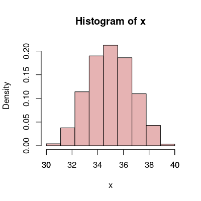

    When a symmetric distribution is sampled thoroughly ($n>100$), you can use the following rules of thumb to **estimate** the mean and standard deviation.

    | Shape | Estimated mean | Estimated standard deviation |
    | --- | --- | --- |
    | Bell | $\frac{\min(x)+\max(x)}{2}$ | $\frac{\max(x)-\min(x)}{6}$ |
    | Uniform | $\frac{\min(x)+\max(x)}{2}$ | $\frac{\max(x)-\min(x)}{\sqrt{12}}$ |
    | Bimodal | $\frac{\min(x)+\max(x)}{2}$ | $\frac{\max(x)-\min(x)}{2}$ |

    1. Estimate the mean of the sample. (Please use the given formula.)
    2. Estimate the standard deviation of the sample. (Please use the given formula.)

#### Question

30. Three large samples were taken from three different populations. Their distributions are shown as histograms.

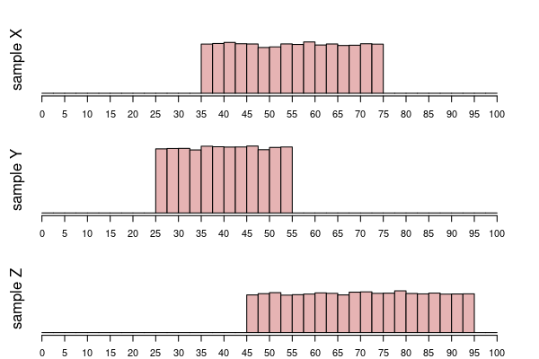

    1. Which sample has the smallest mean? X / Y / Z
    2. Which sample has the largest mean? X / Y / Z
    3. Which sample has the smallest standard deviation? X / Y / Z
    4. Which sample has the largest standard deviation? X / Y / Z

#### Question

31. Three large samples were taken from three different populations. Their distributions are shown as histograms.

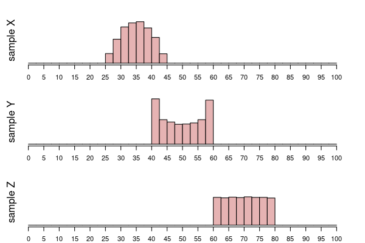

    1. Which sample has the smallest mean? X / Y / Z
    2. Which sample has the largest mean? X / Y / Z
    3. Which sample has the smallest standard deviation? X / Y / Z
    4. Which sample has the largest standard deviation? X / Y / Z

#### Question

### Background

32. Sometimes a population is well characterized. In this case we know its mean and standard deviation. We use greek letters $\mu$ (“mu”) and $\sigma$ (“sigma”) when describing the population (instead of the $\bar{x}$ (“xbar”) and $s$ used for sample mean and sample standard deviation).
    $$\mu = \text{population mean}$$
    $$\sigma = \text{population standard deviation}$$

    When measuring individuals from a population, we expect most measurements to be within the *interval of typical measurements*. We will define the interval of typical measurements (using interval notation):
    $$\text{interval of typical measurements} = (\mu-2\sigma,\,\mu+2\sigma)$$
    In other words, we expect we expect most measurements to be between two bounds.
    $$\text{lower bound of interval of typical measurements} = \mu-2\sigma$$
    $$\text{upper bound of interval of typical measurements} = \mu+2\sigma$$

### Actual Question

    A population of lizards has a mean length of $\mu = 77.1$ cm and a standard deviation of $\sigma=8.3$ cm. Determine the interval of typical measurements.
    1. Determine the lower bound of the interval of typical measurements.
    2. Determine the upper bound of the interval of typical measurements.

#### Question

33. The following spinner has a [population mean](https://en.wikipedia.org/wiki/Mean) $\mu = 65$ and a population standard deviation $\sigma=2$. We can think of a spinner as an infinite population from which we can take as many independent measurements from as we want.

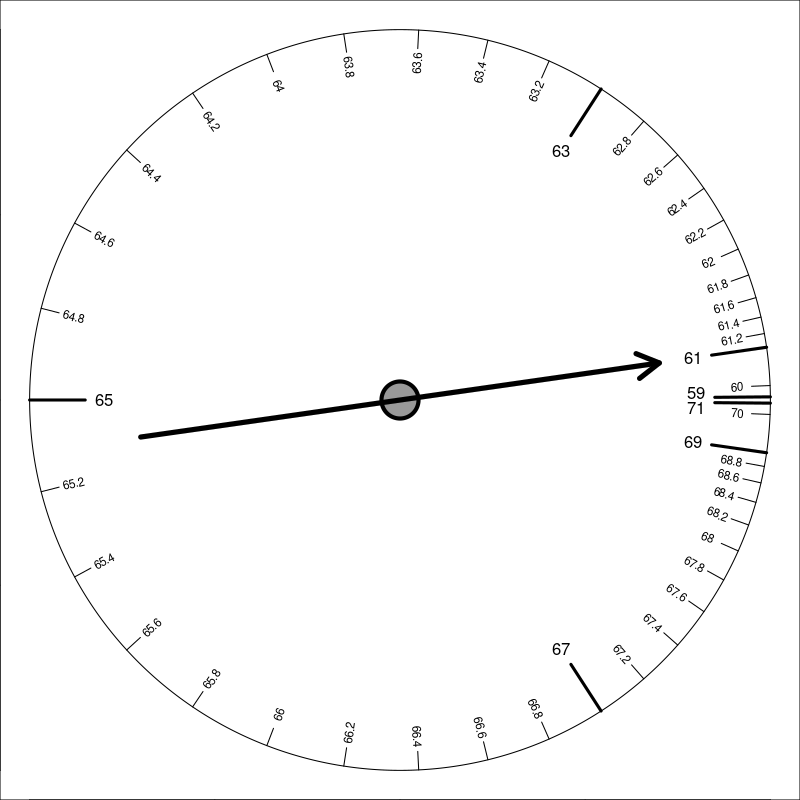

    A sample (200 measurements) was taken.

    ```
    65.5914, 69.6591, 62.3152, 62.0706, 64.2983, 66.9836, 67.3504, 64.5599, 64.4641, 65.8275,
    62.4167, 66.1170, 63.8299, 61.2904, 67.3588, 63.3710, 65.2219, 66.6059, 62.7939, 61.4353,
    68.0023, 65.2899, 67.3512, 65.9362, 65.2307, 68.4660, 65.6860, 66.3906, 65.8748, 62.7641,
    62.5626, 67.4819, 67.3861, 65.0441, 63.3612, 67.0488, 66.5450, 65.0290, 64.0181, 66.5035,
    66.9666, 64.7889, 66.4093, 66.8305, 61.2497, 63.8005, 62.5556, 61.5403, 65.5833, 64.6528,
    66.3852, 63.9360, 67.2303, 62.4962, 64.8687, 67.8652, 62.9088, 68.9563, 62.7787, 64.8576,
    63.8498, 63.5096, 65.7014, 66.0777, 63.1418, 64.9178, 65.6313, 66.4512, 68.1289, 67.5895,
    65.9020, 66.0343, 64.1611, 68.5267, 65.0194, 63.8384, 63.3480, 65.3929, 64.9688, 63.9628,
    66.1697, 66.4425, 66.1182, 63.8994, 64.8656, 59.4777, 64.8277, 64.5477, 62.8686, 64.6629,
    64.1792, 62.8685, 65.2674, 65.4781, 62.3302, 63.9020, 65.5931, 63.7468, 70.1651, 67.6230,
    62.7863, 59.7476, 63.8277, 62.8221, 64.5745, 62.7795, 65.4342, 65.2129, 65.8897, 66.0036,
    62.6035, 65.4064, 65.1463, 66.0459, 61.7113, 63.5175, 65.6731, 68.7174, 66.9093, 67.2812,
    70.8647, 67.4793, 68.6700, 68.3615, 63.8713, 65.2969, 66.6215, 61.9097, 64.6685, 63.6505,
    66.3863, 63.7009, 64.4872, 67.5388, 68.6062, 65.5804, 64.6326, 68.7246, 71.2573, 67.8468,
    66.1906, 66.2312, 65.7185, 64.4274, 67.3468, 62.1675, 64.7659, 61.8738, 67.8193, 65.1262,
    68.0571, 63.0963, 62.6560, 61.7648, 66.6956, 69.2242, 67.5693, 65.5108, 61.6663, 65.0250,
    63.8676, 67.8875, 65.0600, 65.7887, 64.6236, 64.1440, 65.4003, 65.6019, 65.6642, 64.6577,
    67.6506, 64.4485, 65.4193, 68.8963, 66.0985, 64.4691, 62.0262, 66.9004, 63.8215, 64.4759,
    65.3226, 61.4894, 68.3864, 68.1937, 63.7190, 69.1519, 64.8021, 69.4722, 64.5362, 64.1693,
    61.4202, 64.7983, 63.6826, 62.4361, 63.5248, 61.8594, 65.0435, 65.7796, 61.2055, 62.0183
    ```

    You can download the data as a CSV file.

### Actual question

    What **proportion** of the 200 measurements are **outside** the interval of typical measurements?

#### Question

34. A sample was gathered.

    $$\mathbf{x} = 30.54, 45.49, 39.71, 40.32, 49.89, 45.38, 31.16$$

    You can download the data as a CSV file.

    Determine the sample [interquartile range (IQR)](https://en.wikipedia.org/wiki/Interquartile_range).

    Warning: various definitions of IQR exist, based on [arbitrary decisions](https://en.wikipedia.org/wiki/Quantile#Estimating_quantiles_from_a_sample) made in defining the [quantile](https://en.wikipedia.org/wiki/Quantile) function or other definitions of [quartiles](https://en.wikipedia.org/wiki/Quartile#Discrete_Distributions). I will make the answer’s tolerance large enough to accept most (hopefully all) methods.

#### Question

35. A sample was gathered.

    $$\mathbf{x} = 0, 0, 1, 1, 1, 1, 0, 0$$

    You can download the data as a CSV file.

    Determine the sample’s [mean absolute deviation (MAD) around the sample proportion](https://en.wikipedia.org/wiki/Average_absolute_deviation#Mean_absolute_deviation_around_a_central_point). You can round your answer to the hundredths place.

#### Question

36. A sample was gathered.

    $$\mathbf{w} = 0, 0, 0, 0, 0, 1, 0, 1, 0, 1$$

    You can download the data as a CSV file.

    Determine the variance of the sample. You can round your final answer to the hundredths place.

#### Question

37. A sample was gathered.

    $$\mathbf{w} = 1, 1, 0, 1, 1, 0, 0, 1, 0, 1, 0, 0, 0, 0, 0, 0$$

    You can download the data as a CSV file.

    Determine the standard deviation of the sample. Because the data are all 0s and 1s, you would never make Bessel’s correction (even if guessing the population’s standard deviation), because the mean and standard deviation are not independent parameters. You can round your final answer to the hundredths place.

#### Question

38. A sample was taken from an unknown population. The values were organized into a [boxplot](https://en.wikipedia.org/wiki/Box_plot).

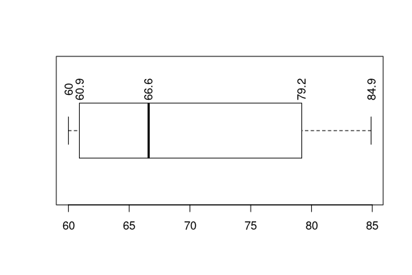

    For simplicity, assume no measurements lie on the hinges, median, or whisker tips (so we do not worry about inclusive vs. exclusive boundaries). This assumption is approximately true with a very large sample from a continuous distribution.
    1. What proportion of measurements are below 84.9?
       $$\text{prop}[\mathbf{x}< 84.9] = \text{?}$$
    2. What proportion of measurements are above 60?
       $$\text{prop}[\mathbf{x}> 60] = \text{?}$$
    3. What proportion of measurements are between 79.2 and 84.9?
       $$\text{prop}[79.2< \mathbf{x} < 84.9] = \text{?}$$
    4. What proportion of measurements are closer than 3.3 units from 63.3?
       $$\text{prop}[|\mathbf{x}-63.3|<3.3] = \text{?}$$
    5. Determine boundary $b$ such that $\text{prop}[\mathbf{x}<b]=0.25$.
    6. Determine boundary $b$ such that $\text{prop}[\mathbf{x}>b]=0.5$.
    7. What is the range?
    8. What is the interquartile range (IQR)?
    9. What is the median?

#### Question

39. Five different populations were sampled, and the measurements were visualized as five [boxplots](https://en.wikipedia.org/wiki/Box_plot). (Note: typical boxplots indicate outliers with dots. For simplicity, these boxplots include all outliers in the whiskers.)

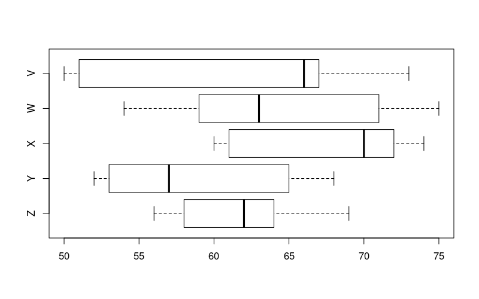

    1. Which sample contains the largest value? V / W / X / Y / Z
    2. Which sample contains the smallest value? V / W / X / Y / Z
    3. Which sample has the largest median? V / W / X / Y / Z
    4. Which sample has the smallest median? V / W / X / Y / Z
    5. Which sample has the largest IQR? V / W / X / Y / Z
    6. Which sample has the smallest IQR? V / W / X / Y / Z

#### Question

40. Match the five [boxplots](https://en.wikipedia.org/wiki/Box_plot) with their appropriate description.

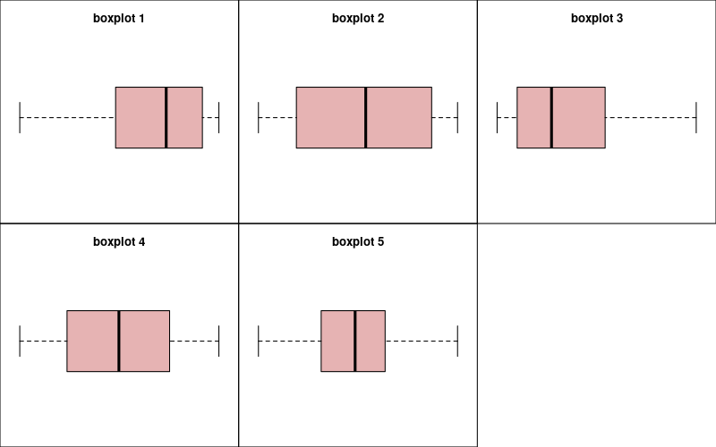

    1. Bell (Enter an integer between 1 and 5)
    2. Right-skew (Enter an integer between 1 and 5)
    3. Bimodal (Enter an integer between 1 and 5)
    4. Uniform (Enter an integer between 1 and 5)
    5. Left-skew (Enter an integer between 1 and 5)

#### Question

41. A continuous random variable (spinner/random number generator/infinite population) can be visualized with a density curve, a spinner, and a cumulative curve.

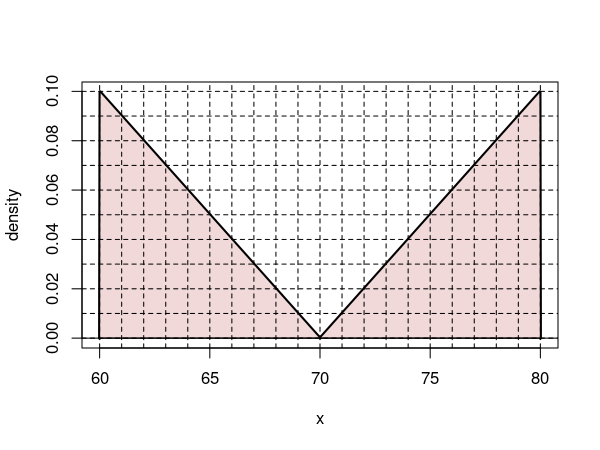

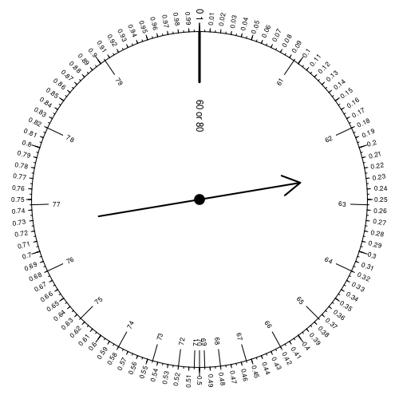

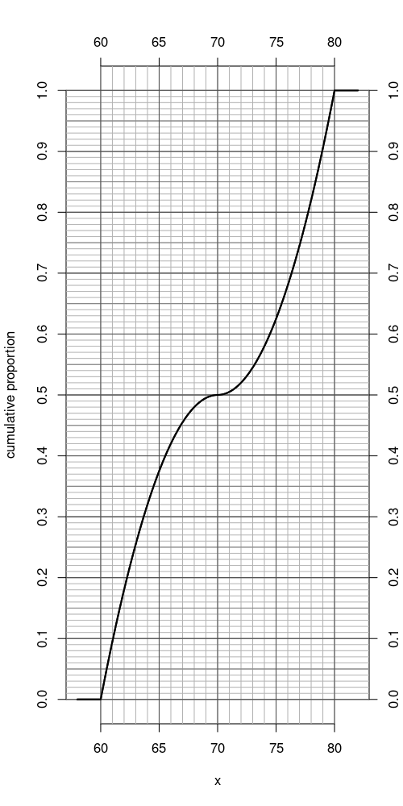

    1. Evaluate $\text{prop}[\mathbf{x}<70]$
    2. Evaluate $\text{prop}[\mathbf{x}>68]$
    3. Evaluate $\text{prop}[|\mathbf{x}-70|<8]$
    4. Determine integer $b$ such that $\text{prop}[\mathbf{x}<b]=0.42$
    5. Determine integer $b$ such that $\text{prop}[\mathbf{x}>b]=0.42$
    6. Determine integer $r$ such that $\text{prop}[|\mathbf{x}-74|<r]=0.16$

#### Question

### Background

42. In statistics, the word “normal” does not mean “typical”. Instead, “normal” refers to a very important continuous distribution: the [normal distribution](https://en.wikipedia.org/wiki/Normal_distribution). Normal distributions are important because random sums and random averages are approximately normal (see [central limit theorem](https://en.wikipedia.org/wiki/Central_limit_theorem)). For example, if you repeatedly roll 100 dice, taking the sum of each 100, those sums will be normally distributed (even though single rolls are [discrete-uniform](https://en.wikipedia.org/wiki/Discrete_uniform_distribution)ly distributed).

    A normal distribution has a bell-shaped density curve. The center and spread of the bell are dictated by two parameters: [mean](https://en.wikipedia.org/wiki/Mean) ($\mu$) and [standard deviation](https://en.wikipedia.org/wiki/Standard_deviation) ($\sigma$). The normal density curve is defined by the following equation:
    $$\text{normal density as function of x} = \frac{1}{\sigma\sqrt{2\pi}}e^{-\frac{1}{2}\left(\frac{x-\mu}{\sigma}\right)^2}$$
    where $\mu$ is the mean, $\sigma$ is the standard deviation, $\pi$ is the [ratio of a circle’s circumference to its diameter](https://en.wikipedia.org/wiki/Pi), and $e$ is Euler’s number.

    For the first exam, we are expected to know [the empirical rule](https://en.wikipedia.org/wiki/68%E2%80%9395%E2%80%9399.7_rule). We are going to round unconventionally, so for us it could be called the “68-96-100 rule”. It implies that in a normal distribution 68% of the measurements are within 1 standard deviation of the mean, 96% of the measurements are within 2 standard deviations of the mean, and 100% of the measurements are within 3 standard deviations of the mean.

    We can visualize the “68-96-100” rule with a density curve. Notice the area of each region is shown, and you can estimate the areas by counting percentage boxes.

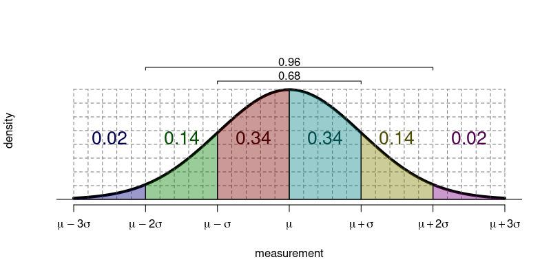

    We can display our 68-96-100 rule with a spinner.

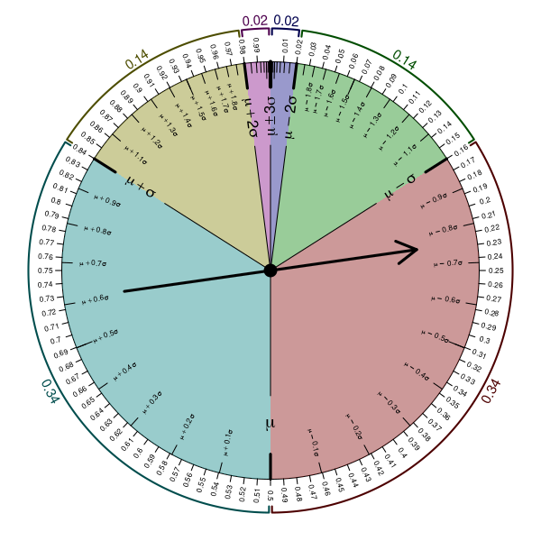

    And, we can display our 68-96-100 rule with a cumulative curve. In this case, we will introduce the notation of using $z$ as the multiplier of $\sigma$. For example, if $z=-2$, then the measurement is $\mu-2\sigma$. We call $z$ the [standard score](https://en.wikipedia.org/wiki/Standard_score).

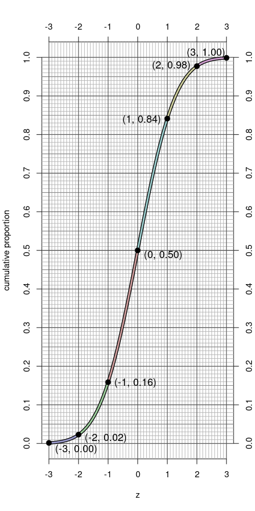

### Actual Question:

    Population $X$ (with infinite individuals) has measurements that are normally distributed with mean $\mu=50$ and standard deviation $\sigma=10$. Use the empirical rule (68-96-100 rule) to answer the following questions.
    1. Evaluate $\text{prop}[X<40]$.
    2. Evaluate $\text{prop}[X>50]$.
    3. Evaluate $\text{prop}[|X-50|<20]$.
    4. Determine boundary $b$ such that $\text{prop}[X<b]=0.84$.
    5. Determine boundary $b$ such that $\text{prop}[X>b]=0.02$.
    6. Determine radius $r$ such that $\text{prop}[|X-50|<r]=0.68$.

#### Question

### Background

43. A [standard score](https://en.wikipedia.org/wiki/Standard_score) ($z$) can be calculated from a measurement ($x$), the population mean ($\mu$), and the population standard deviation ($\sigma$).
    $$z = \frac{x-\mu}{\sigma}$$
    With a little algebra, you can create another formula solved for the measurement.
    $$x = \mu+z\sigma$$

### Actual question

    A gambler is interested in the sum of 160 rolls of 4-sided dice. The process of summing 160 rolls of 4-sided dice can be repeated infinitely many times, giving independent results each time, so those sums can be thought of as an infinitely large population. This population happens to be approximately normal (see [central limit theorem](https://en.wikipedia.org/wiki/Central_limit_theorem)).

    The gambler knows how to calculate the population mean (see [discrete-uniform distribution](https://en.wikipedia.org/wiki/Discrete_uniform_distribution)).
    $$\mu = 160\cdot\frac{1+4}{2} = 400$$
    She also knows how to calculate the population standard deviation.
    $$\sigma = \sqrt{160} \cdot \sqrt{\frac{4^2-1}{12}} = 14.14$$
    1. If the gambler rolled a sum of 419 (in other words got a measurement $x=419$), what is the standard score? (Determine $z$; you can round to the nearest hundredth.)
    2. If the gambler got a standard score of $z=0.21$, what is the sum? (Determine $x$, rounding to the nearest integer.)

#### Question

44. A sample’s statistic typically approaches its corresponding population parameter, but with a small sample size there is regularly error. Let’s explore this idea with an example.

    A [geometric distribution](https://en.wikipedia.org/wiki/Geometric_distribution) is a well-studied discrete population. The spinner below represents a geometric distribution with the following population parameters.
    $$\mu = 5.01$$
    $$\sigma = 5.49$$

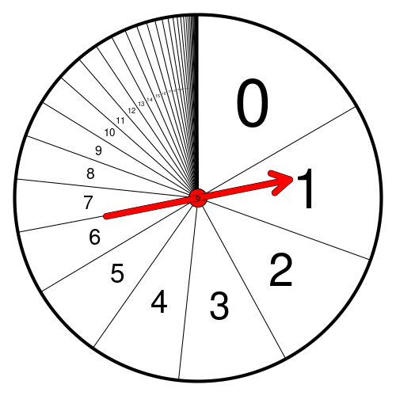

    That spinner was spun many times. The raw data is displayed below and can be downloaded as a CSV.

    ```
    11, 1, 1, 17, 3, 1, 18, 2, 3, 1, 0, 6, 2, 12, 16, 4, 5, 17, 9, 0, 11, 0, 0, 2, 12, 6, 1, 0, 9, 0, 4, 10, 0, 4, 16, 1, 2, 2, 2, 10, 0, 3, 8, 4, 8, 4, 9, 0, 53, 27, 0, 5, 0
    ```

    Please calculate the following sample statistics.
    1. What is the sample size? (Determine $n$.)
    2. What is the sample mean? (Determine $\bar{x}$. You can round to nearest hundredth.)
    3. What is the **absolute difference** between the sample mean and population mean? (Calculate $|\bar{x}-\mu|$. You can round to nearest hundredth.)
    4. What is the sample median?
    5. What is the sample variance? (Determine $s^2$. Use Bessel’s correction. You can round to nearest hundredth.)
    6. What is the sample standard deviation? (Determine $s$. Use Bessel’s correction. You can round to nearest hundredth.)
    7. What is the **absolute difference** between the sample standard deviation and population standard deviation? (Calculate $|s-\sigma|$. You can round to nearest hundredth.)

#### Question

45. A [normal distribution](https://en.wikipedia.org/wiki/Geometric_distribution) is a well-studied continuous population. The spinner below represents a normal distribution with the following population parameters.
    $$\mu = 50$$
    $$\sigma = 8$$

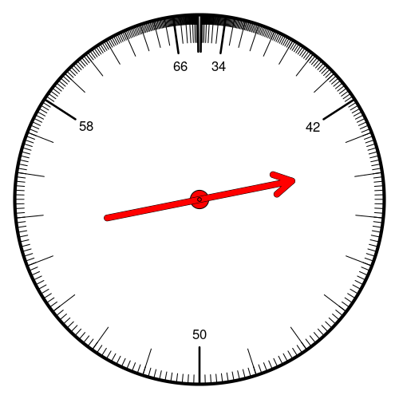

    That spinner was spun many times. The raw data is displayed below and can be downloaded as a CSV.

    ```
    46.1334, 46.5424, 47.8209, 35.8491, 41.2869, 51.1657, 46.4394, 44.1339, 43.8125, 44.9495, 44.8426, 60.0421, 51.0485, 55.4653, 55.2529, 37.767, 54.026, 63.5898, 34.3265, 47.3499, 52.8916, 46.2517, 45.3903, 64.2519, 40.937, 60.1959, 53.3353, 53.0661, 49.5026, 58.5484, 55.6279, 52.2783, 36.2523, 55.7074, 34.5496, 37.9945, 62.39, 67.77, 37.5741, 39.4837, 43.6251, 33.3043, 51.8723, 49.5009, 47.3149, 60.925, 59.945, 51.1887
    ```

    Please calculate the following sample proportions. (All answers can be rounded to nearest hundredth.)
    1. Calculate $\text{prop}[\mathbf{x}<47]$.
    2. Calculate $\text{prop}[\mathbf{x}>57.4]$.
    3. Calculate $\text{prop}[|\mathbf{x}-50|<2.2]$.
    4. Calculate $\text{prop}[|\mathbf{x}-50|>3]$.

#### Question

46. A standard eight-sided [die](https://en.wikipedia.org/wiki/Dice) was rolled many times, and the results were organized into the [histogram](https://en.wikipedia.org/wiki/Histogram) shown below.

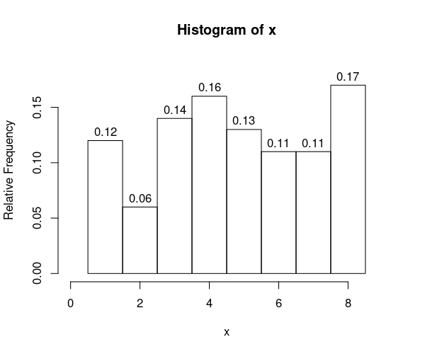

    1. Evaluate $\text{prop}[\mathbf{x}<2.5]$.
    2. Evaluate $\text{prop}[\mathbf{x}>3.5]$.
    3. Evaluate $\text{prop}[|\mathbf{x}-4.5|<2]$.
    4. Evaluate $\text{prop}[|\mathbf{x}-4|>2.5]$.
    5. Evaluate half-integer boundary $b$ such that $\text{prop}[\mathbf{x}<b] = 0.72$.
    6. Evaluate half-integer boundary $b$ such that $\text{prop}[\mathbf{x}>b] = 0.88$.
    7. Evaluate half-integer radius $r$ such that $\text{prop}[|\mathbf{x}-5|<r] = 0.65$.
    8. Evaluate half-integer radius $r$ such that $\text{prop}[|\mathbf{x}-4|>r] = 0.57$.

#### Question

47. Three large samples were taken from three different populations. Their distributions are shown as histograms.

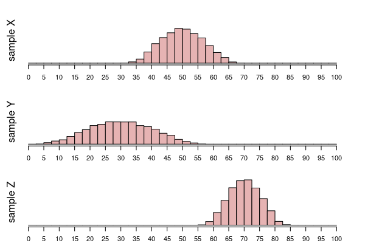

    1. Which sample has the smallest mean? X / Y / Z
    2. Which sample has the largest mean? X / Y / Z
    3. Which sample has the smallest standard deviation? X / Y / Z
    4. Which sample has the largest standard deviation? X / Y / Z

#### Question

48. Three large samples were taken from three different populations. Their distributions are shown as histograms.

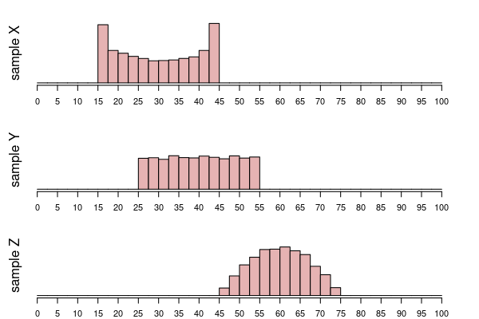

    1. Which sample has the smallest mean? X / Y / Z
    2. Which sample has the largest mean? X / Y / Z
    3. Which sample has the smallest standard deviation? X / Y / Z
    4. Which sample has the largest standard deviation? X / Y / Z

#### Question

49. Five different populations were sampled, and the measurements were visualized as five [boxplots](https://en.wikipedia.org/wiki/Box_plot). (Note: typical boxplots indicate outliers with dots. For simplicity, these boxplots include all outliers in the whiskers.)

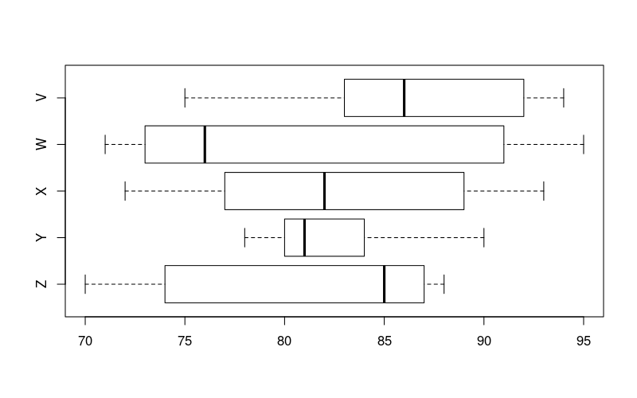

    1. Which sample contains the largest value? V / W / X / Y / Z
    2. Which sample contains the smallest value? V / W / X / Y / Z
    3. Which sample has the largest median? V / W / X / Y / Z
    4. Which sample has the smallest median? V / W / X / Y / Z
    5. Which sample has the largest IQR? V / W / X / Y / Z
    6. Which sample has the smallest IQR? V / W / X / Y / Z

#### Question

50. When measuring individuals from a population, we expect most measurements to be within the *interval of typical measurements*. We will define the interval of typical measurements (using interval notation):
    $$\text{interval of typical measurements} = (\mu-2\sigma,\,\mu+2\sigma)$$
    In other words, we expect we expect most measurements to be between two bounds.
    $$\text{lower bound of interval of typical measurements} = \mu-2\sigma$$
    $$\text{upper bound of interval of typical measurements} = \mu+2\sigma$$

### Actual Question

    A population of lizards has a mean length of $\mu = 72.5$ cm and a standard deviation of $\sigma=4.0$ cm. Determine the interval of typical measurements.
    1. Determine the lower bound of the interval of typical measurements.
    2. Determine the upper bound of the interval of typical measurements.

#### Question

51. We can visualize the “68-96-100” rule with a density curve. Notice the area of each region is shown, and you can estimate the areas by counting percentage boxes.

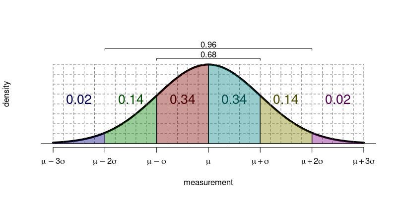

    Population $X$ has measurements that are normally distributed with mean $\mu=70$ and standard deviation $\sigma=9$. Use the empirical rule (68-96-100 rule) to answer the following questions.
    1. Evaluate $\text{prop}[X<88]$.
    2. Evaluate $\text{prop}[X>79]$.
    3. Evaluate $\text{prop}[|X-70|<18]$.
    4. Determine boundary $b$ such that $\text{prop}[X<b]=0.02$.
    5. Determine boundary $b$ such that $\text{prop}[X>b]=0.5$.
    6. Determine radius $r$ such that $\text{prop}[|X-70|<r]=0.68$.

#### Question

52. A [standard score](https://en.wikipedia.org/wiki/Standard_score) ($z$) can be calculated from a measurement ($x$), the population mean ($\mu$), and the population standard deviation ($\sigma$).
    $$z = \frac{x-\mu}{\sigma}$$

    The following (normal) spinner has population mean $\mu=50$ and population standard deviation $\sigma=7$.

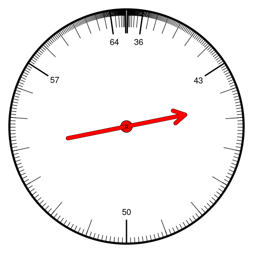

    1. If a spin has a measurement $x=69.25$, what is the standard score ($z$)?
    2. If a spin has a standard score $z=-2.68$, what is the measurement ($x$)?

#### Question

53. A sample of size $n=400$ was taken from an unknown population.

    ```
     3.13, 8.95, 8.53, 2.79, 7.41, 8.11, 9.97, 5.88, 8.32, 8.19,
     1.80, 9.17, 8.28, 9.98, 5.46, 7.92, 9.84, 9.76, 9.83, 7.19,
     9.42, 5.17, 9.64, 8.93, 9.33, 8.15, 5.50, 9.77, 4.66, 9.29,
     6.11, 7.85, 4.25, 1.06, 9.99, 8.34, 7.05, 3.47, 9.18, 8.54,
     6.33, 8.51, 8.59, 6.33, 6.69, 9.33, 8.95, 9.62, 6.29, 1.10,
     4.18, 7.61, 7.76, 9.96, 7.77, 5.42, 9.01, 8.22, 9.09, 6.29,
     6.85, 7.57, 9.77, 2.63, 5.30, 9.24, 6.38, 5.54, 8.23, 3.57,
     8.88, 6.72, 7.92, 9.03, 9.54, 6.28, 0.68, 7.64, 9.43, 2.78,
     9.67, 9.90, 5.71, 2.13, 9.20, 8.59, 9.09, 8.91, 6.27, 9.68,
     7.65, 7.45, 9.88,10.00, 2.87, 8.64, 5.20, 9.97, 9.45, 5.26,
     4.88, 8.99, 8.51, 8.16, 6.26, 9.92, 6.13, 6.89, 4.66, 9.73,
     8.64, 3.05, 7.90, 5.81, 6.18, 7.78, 5.11, 3.55, 3.47, 8.65,
     7.12, 4.50,10.00, 5.14, 4.71, 3.44, 8.41, 8.90, 8.41, 4.66,
     9.46, 8.49, 9.89, 9.49, 9.85, 8.81, 9.88, 5.90, 9.89, 8.98,
     8.86, 2.96, 2.73, 8.74, 7.19, 9.91, 9.16, 5.76, 5.58, 5.05,
     5.55, 9.85, 7.14, 7.74, 9.22, 2.38, 9.38, 3.13, 2.59, 7.61,
     5.49, 9.61, 9.43, 7.09, 4.31, 9.02, 4.04, 9.21, 8.86, 4.00,
     7.73, 2.48, 8.30, 8.46, 8.77, 9.91, 4.55, 8.11, 4.93, 5.33,
     6.33, 7.84, 7.44, 8.33, 7.86, 2.12, 4.73, 1.39, 8.17, 9.50,
     8.79, 9.55, 6.41, 3.58, 8.60, 7.98, 6.95, 7.91,10.00, 9.30,
     8.50, 3.22, 2.43, 8.57, 9.23, 4.02, 7.51, 8.59, 9.97, 7.40,
     7.47, 9.92, 7.83, 9.90, 9.69, 9.99, 8.18, 2.74, 7.30, 9.81,
     5.64, 3.90, 9.62, 4.12, 9.35, 3.17, 2.37, 2.32, 9.61, 9.99,
     7.98, 9.80, 5.58, 2.69, 4.08, 5.90, 5.93, 9.64, 1.70, 6.93,
     8.03, 9.63, 9.19, 1.34, 9.13, 3.55, 4.62, 1.98, 2.45, 8.35,
     7.36, 8.12, 9.98, 7.03, 8.07, 8.31, 1.65, 7.44, 7.47, 9.16,
     1.08, 4.48, 6.76, 5.39, 9.84, 6.44, 6.91, 5.93, 6.66, 6.13,
     8.63, 9.97, 6.06, 8.91, 5.15, 3.50, 9.93, 4.64, 9.97, 9.71,
     5.61, 2.08, 6.91, 9.82, 5.93, 4.90, 8.17, 7.26, 9.38,10.00,
     9.98, 7.18, 9.65, 4.25, 9.68,10.00, 9.34, 8.23, 9.93, 9.88,
     9.71, 2.52, 9.30, 5.83, 4.73, 7.59, 3.31, 2.88, 3.29, 9.36,
     9.25, 5.06, 4.99, 9.51, 9.42, 2.12, 9.71, 8.97, 9.62, 9.84,
     4.52, 6.58, 6.99, 1.28, 0.63, 9.78, 8.10, 8.96, 6.83, 9.52,
     3.23, 8.92, 9.95, 9.93, 2.78, 8.98, 9.37, 8.21, 8.64, 8.33,
     2.28, 9.55, 9.55, 7.29, 7.72, 8.02, 5.41, 8.06, 0.93, 9.07,
     6.25, 3.53, 8.79, 5.95, 5.55, 8.93, 9.52, 7.61, 9.82, 3.24,
     2.70, 5.53, 8.79, 7.90, 5.51, 8.72, 5.96, 7.66, 8.68, 9.99,
     9.82, 4.69, 9.36, 2.51, 6.62, 8.78, 3.27, 6.43, 9.19, 7.31,
     7.72, 8.66, 9.99, 9.46, 5.48, 9.39, 9.95, 4.96, 8.71, 8.91,
     1.47, 5.96, 2.92, 9.13, 8.89, 9.86, 8.80, 8.85, 6.93, 9.94
    ```

    You can download the data as a CSV. Determine which histogram visualizes the data, and describe the shape of the data.

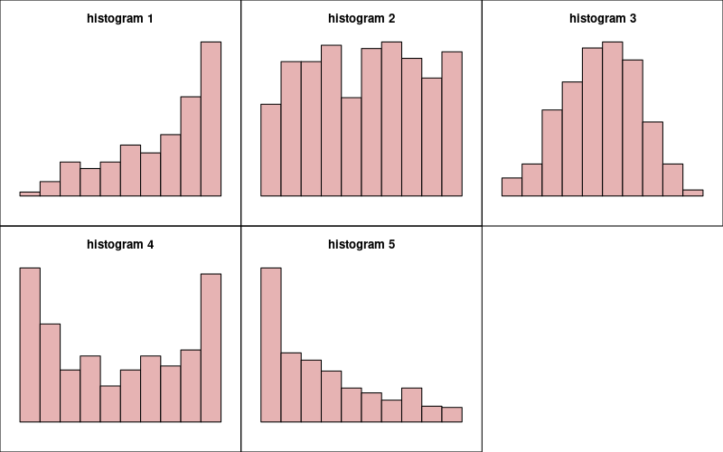

    - Which histogram is appropriate? distribution 1 / distribution 2 / distribution 3 / distribution 4 / distribution 5
    - Which shape description is appropriate? Bell / Uniform / Bimodal / Right-skew / Left-skew

#### Question

54. In a deck of strange cards, there are 426 cards. Each card has an image and a color. The amounts are shown in the table below and can be downloaded as a csv.

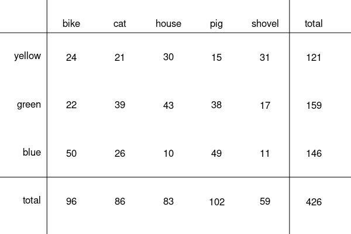

    (Answers can be rounded to nearest hundredth.)
    1. A house is more likely than a pig to be blue. / A pig is more likely than a house to be blue.
    2. What is the probability a random card is a cat?
    3. What is the probability a random card is a bike given it is blue?
    4. What is the probability a random card is yellow given it is a house?
    5. What is the probability a random card is either a cat or blue (or both)?
    6. What is the probability a random card is both a house and blue?
    7. What is the probability a random card is blue?

#### Question

55. A spinner was constructed:

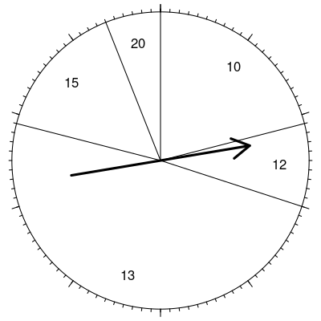

    The spinner’s probability distribution is shown below.

    | $x$ | $\mathbb{P}[x]$ |
    | --- | --- |
    | 10 | 0.21 |
    | 12 | 0.09 |
    | 13 | 0.49 |
    | 15 | 0.15 |
    | 20 | 0.06 |

    It can also be downloaded as a csv.
    1. What is the probability of spinning 13? In other words, what is $\mathbb{P}[X=13]$?
    2. What is the probability of spinning 10 or 15? In other words, what is $\mathbb{P}[X=10 ~\text{ or }~ X=15]$?
    3. If spinning twice, what is the probability of first spinning 10 and then spinning 15? In other words, what is $\mathbb{P}[X_1=10 ~\text{ and }~ X_2=15]$?
    4. What is the probability of spinning at least 13? In other words, what is $\mathbb{P}[X\ge 13]$?
    5. Determine the mean of the probability distribution by using $\mu = \sum x\cdot \mathbb{P}[x]$.
    6. Determine the standard deviation of the probability distribution by using $\sigma = \sqrt{\sum (x-\mu)^2 \cdot \mathbb{P}[x]}$.

#### Question

56. A pizza shop has 14 different toppings available. You will choose 4 different toppings for your pizza. How many possibilities exist?

#### Question

57. Joe is shopping for shirts. Joe likes 17 of the shirts, but will only buy 4 of them. How many possibilities exist?

#### Question

58. A company needs to select a CFO, a president, and a secretary. Each position will be held by a different person. The company is considering the same pool of 24 applicants for each position. How many possibilities exist?

#### Question

59. A team has 20 players. The coach will give out 5 different prizes to different players. How many ways could the coach do this?

#### Question

60. In some situation, each trial has 0.61 probability of success. There will be 10 trials. (Thus the number of successes will follow a [binomial distribution](https://en.wikipedia.org/wiki/Binomial_distribution).)
    1. What is the probability of getting exactly 3 successes? In other words, determine $\mathbb{P}[X = 3]$.
    2. What is the probability of getting exactly 8 successes? In other words, determine $\mathbb{P}[X = 8]$.
    3. What is the probability of getting more than 8 successes? In other words, determine $\mathbb{P}[X > 8]$.
    4. What is the probability of getting at least 8 successes? In other words, determine $\mathbb{P}[X \ge 8]$.
    5. What is the probability of getting less than 8 successes? In other words, determine $\mathbb{P}[X < 8]$.
    6. What is the probability of getting at most 8 successes? In other words, determine $\mathbb{P}[X \le 8]$.
    7. Determine the mean number of successes.
    8. Determine the standard deviation of successes.

#### Question

61. Bob has a 0.69 chance of winning a game. If Bob wins, he has a 0.48 chance of being happy after the game. If Bob loses, he has a 0.21 chance of being happy after the game.

    After the game, you notice Bob is happy. What is the probability that Bob won his game? (Do not answer as a percentage; answer as a decimal.)

#### Question

62. Cindy has two games today. Each game she will either win or lose. She has a 0.34 chance of winning the first game and a 0.79 chance of winning the second game.
    1. What is the chance Cindy wins both games?
    2. What is the chance Cindy loses both games?
    3. What is the chance Cindy wins once and loses once (in either order)?

#### Question

63. Determine the probability that the standard normal variable is less than -0.87. In other words, evaluate $P(Z < -0.87)$.

#### Question

64. Determine the probability that the standard normal variable is more than 0.05. In other words, evaluate $P(Z > 0.05)$.

#### Question

65. Determine the probability that the **absolute** standard normal variable is less than 0.89. In other words, evaluate $P\left(|Z| < 0.89\right)$.

#### Question

66. Determine the probability that the **absolute** standard normal variable is more than 0.56. In other words, evaluate $P\left(|Z| > 0.56\right)$.

#### Question

67. Determine the probability that the standard normal variable is between -1.35 and -0.16. In other words, evaluate $P(-1.35 < Z < -0.16)$.

#### Question

68. Determine $z$ such that $P(Z<z)=0.41$. In other words, what $z$-score is greater than $41$% of standard normal values? (Answers within 0.01 from the correct value will be marked correct.)

#### Question

69. Determine $z$ such that $P(Z>z)=0.94$. In other words, what $z$-score is less than $94$% of standard normal values? (Answers within 0.01 from the correct value will be marked correct.)

#### Question

70. Determine $z$ such that $P(|Z|<z)=0.54$. In other words, how far from 0 should boundaries be set such that 54% of standard normal values are between those boundaries? (Answers within 0.01 from the correct value will be marked correct.)

#### Question

71. Determine $z$ such that $P(|Z|>z)=0.2$. In other words, how far from 0 should boundaries be set such that 20% of standard normal values are outside those boundaries? (Answers within 0.01 from the correct value will be marked correct.)

#### Question

72. A farm produces 4 types of fruit: kiwis, plums, apricots, and apples. The fruits’ masses follow normal distributions, with population parameters dependent on the type of fruit.

    | _ Type of fruit _ | _ Mean mass (g) _ | _ Standard deviation of mass (g) _ |
    | --- | --- | --- |
    | kiwis | 95 | 8 |
    | plums | 105 | 8 |
    | apricots | 43 | 4 |
    | apples | 214 | 12 |

    One specimen of each type is weighed. The results are shown below.

    | _ Specimen type _ | _ Mass of specimen (g) _ |
    | --- | --- |
    | kiwi | 103.2 |
    | plum | 100.8 |
    | apricot | 42 |
    | apple | 203.9 |

    The population parameters and specimen masses can be downloaded as a csv.

    For each measurement, determine the [standard score](https://en.wikipedia.org/wiki/Standard_score) and the [cumulative probability](https://en.wikipedia.org/wiki/Cumulative_distribution_function). Then determine which specimen is most unusually large, most unusually small, most typically sized, and most unusually sized.
    1. Calculate a $z$ score for the kiwi specimen. (Round to the nearest hundredth.)
    2. What proportion of kiwis have less mass than the kiwi specimen?
    3. Calculate a $z$ score for the plum specimen. (Round to the nearest hundredth.)
    4. What proportion of plums have less mass than the plum specimen?
    5. Calculate a $z$ score for the apricot specimen. (Round to the nearest hundredth.)
    6. What proportion of apricots have less mass than the apricot specimen?
    7. Calculate a $z$ score for the apple specimen. (Round to the nearest hundredth.)
    8. What proportion of apples have less mass than the apple specimen?
    9. The kiwi specimen is most unusually large. / The plum specimen is most unusually large. / The apricot specimen is most unusually large. / The apple specimen is most unusually large.
    10. The kiwi specimen is most unusually small. / The plum specimen is most unusually small. / The apricot specimen is most unusually small. / The apple specimen is most unusually small.
    11. The kiwi specimen is most typically sized. / The plum specimen is most typically sized. / The apricot specimen is most typically sized. / The apple specimen is most typically sized.
    12. The kiwi specimen is most unusually sized. / The plum specimen is most unusually sized. / The apricot specimen is most unusually sized. / The apple specimen is most unusually sized.

#### Question

73. Random variable $D$ is [normally distributed](https://en.wikipedia.org/wiki/Normal_distribution) with mean $\mu = 40$ and standard deviation $\sigma = 10$.
    $$D = \text{N}(40,\,10)$$
    Evaluate $P(D < 37)$.

#### Question

74. Random variable $H$ is normally distributed with mean $\mu = 86$ and standard deviation $\sigma = 21$.
    $$H = \text{N}(86,\,21)$$
    Evaluate $P(H > 107)$.

#### Question

75. Random variable $W$ is normally distributed with mean $\mu = 75$ and standard deviation $\sigma = 4$.
    $$W = \text{N}(75,\,4)$$
    Evaluate $P\left(\big|W-75\big| < 5\right)$. In other words, what is the probability that $W$ is within $\pm5$ units from the mean?

#### Question

76. Random variable $Q$ is normally distributed with mean $\mu = 0.16$ and standard deviation $\sigma = 0.05$.
    $$Q = \text{N}(0.16,\,0.05)$$
    Evaluate $P\left(\big|Q-0.16\big| > 0.11\right)$. In other words, what is the probability that $Q$ is outside $\pm0.11$ units from the mean?

#### Question

77. Random variable $H$ is normally distributed with mean $\mu = 180$ and standard deviation $\sigma = 40$.
    $$H = \text{N}(180,\,40)$$
    Evaluate $P\left(210 < X < 220\right)$. In other words, what is the probability that $H$ is between $210$ and $220$?

#### Question

78. Random variable $B$ is normally distributed with mean $\mu = 9.6$ and standard deviation $\sigma = 2.6$.
    $$B = \text{N}(9.6,\,2.6)$$
    Evaluate $b$ such that $P(B<b) = 0.39$. In other words, determine an upper boundary such that a normal spinner with mean 9.6 and standard deviation 2.6 lands under that boundary 39% of the time.

#### Question

79. Random variable $K$ is normally distributed with mean $\mu = 35$ and standard deviation $\sigma = 7$.
    $$K = \text{N}(35,\,7)$$
    Evaluate $k$ such that $P(K>k) = 0.94$. In other words, determine an lower boundary such that a normal spinner with mean 35 and standard deviation 7 lands on a value more than that boundary 94% of the time.

#### Question

80. Random variable $Y$ is normally distributed with mean $\mu = 8.3$ and standard deviation $\sigma = 1.7$.
    $$Y = \text{N}(8.3,\,1.7)$$
    1. Evaluate $d$ such that $P\left(\big|Y-8.3\big|<d\right) = 0.2$. In other words, determine the distance from mean of two boundaries such that this normal spinner lands within those boundaries 20% of the time.
    2. Let $y_1 = 8.3-d$ and $y_2 = 8.3+d$, such that $P\left(y_1 < Y < y_2\right) = 0.2$. Evaluate $y_1$.
    3. Using the definitions above, evaluate $y_2$

#### Question

81. Random variable $V$ is normally distributed with mean $\mu = 600$ and standard deviation $\sigma = 130$.
    $$V = \text{N}(600,\,130)$$
    1. Evaluate $d$ such that $P\left(\big|V-600\big|>d\right) = 0.7$. In other words, determine the distance from mean of two boundaries such that this normal spinner lands outside those boundaries 70% of the time.
    2. Let $v_1 = 600-d$, such that $P\left(V < v_1\right) = \frac{0.7}{2}$. Evaluate $v_1$.
    3. Let $v_2 = 600+d$, such that $P\left(V > v_2\right) = \frac{0.7}{2}$. Evaluate $v_2$.

#### Question

82. This question provides $\mu$, $\sigma$, $n$, and $\bar{x}$. You will characterize the sampling distribution, calculate the standard score, determine the percentile rank (expressed as a decimal), and translate the score into a rating (see below).

### Population

    When Archie practices archery, each arrow has the same probability distribution (see [i.i.d](https://en.wikipedia.org/wiki/Independent_and_identically_distributed_random_variables)). This means her skill is constant, there is no [hot-hand effect](https://en.wikipedia.org/wiki/Hot_hand), and there is no [maturity of chances](https://en.wikipedia.org/wiki/Gambler%27s_fallacy).

    Over many months, Archie has shot ten thousand arrows (their positions are shown below as dots).

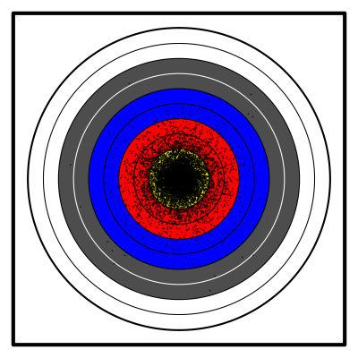

    From those many arrows, Archie has determined an accurate probability distribution (of the points scored by an arrow).

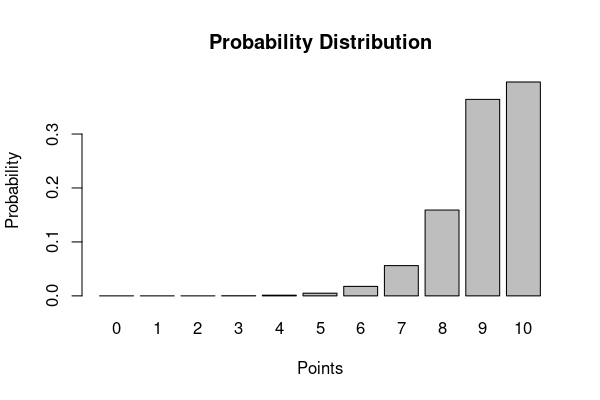

    Thus, Archie can determine her population mean and population standard deviation.
    $$\mu=9.04$$
    $$\sigma=1.03$$

## Sampling distribution

    Each day, Archie shoots 48 arrows ($n=48$) and determines that day’s mean score. A mean of 10 would be a perfect day. We can treat each day’s mean as a random variable with its own probability distribution: a [sampling distribution](https://en.wikipedia.org/wiki/Sampling_distribution). We wish to characterize this sampling distribution. From the [central limit theorem](https://en.wikipedia.org/wiki/Central_limit_theorem), we know the sampling distribution is approximately normal; however, we need to calculate the parameters.

### Expected mean (mean of sampling distribution)

    The expected mean is simply the population mean.
    $$\text{expected mean} = \mu$$

    “Expected mean” is a misnomer. It is not necessarily likely, or even possible, for a mean to equal the expected mean. However, if Archie repeatedly shot 48 arrows, we expect the means to have a average equal to the expected mean. So, maybe “average of means” would be better terminology.

    This expected mean is the average of the sampling distribution.

    Determine the expected mean:

    (Round to the hundredths place)

### Standard error (standard deviation of sampling distribution)

    The standard error of a mean is the quotient of the population standard deviation and the square root of the sample size.
    $$\text{standard error of mean} = \frac{\sigma}{\sqrt{n}}$$
    This standard error is the standard deviation of the sampling distribution.

    Calculate the standard error:

    (Round to the thousandths place)

### Sample

    Today, Archie’s mean score is 9.062 points ($\bar{x} = 9.062$).

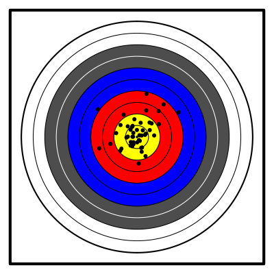

### Standard score

    Archie would like to know how well she did today. She wants you to calculate a standard score (a $z$ score). To calculate the standard score of a sample mean, you can use the following formula.
    $$z = \frac{\bar x - \mu}{\sigma/\sqrt{n}}$$

    Calculate the standard score:

    (Round to the hundredths place)

### Cumulative probability (percentile rank)

    Archie would like to know the probability that tomorrow she shoots worse than today. To estimate this, report the cumulative probability associated with the $z$-score you calculated. This can be done with a [$z$ table](https://en.wikipedia.org/wiki/Standard_normal_table#Conversion), `pnorm` function in R, `NORM.DIST` function in a spreadsheet, or with other standard normal tools.

    Calculate $P(Z\leq z)$, the cumulative probability:

    (Round to the ten-thousandths place)

### Rating

    Archie would like a rating for her day’s performance. You decide to use the following scale and that if $z$ is on a boundary, Archie will be given the higher rating.

    | $z$ interval | rating |
    | --- | --- |
    | $-\infty$ to -1.51 | F |
    | -1.5 to -0.51 | D |
    | -0.5 to 0.49 | C |
    | 0.5 to 1.49 | B |
    | 1.5 to $\infty$ | A |

    Determine Archie’s rating: A / B / C / D / F

#### Question

83. This question provides $\mu$, $\sigma$, $n$, and $\sum x$. You will characterize the sampling distribution, calculate the standard score, determine the percentile rank (expressed as a decimal), and translate the score into a rating (see below).

### Population

    When Archie practices archery, each arrow has the same probability distribution (see [i.i.d](https://en.wikipedia.org/wiki/Independent_and_identically_distributed_random_variables)). This means her skill is constant, there is no [hot-hand effect](https://en.wikipedia.org/wiki/Hot_hand), and there is no [maturity of chances](https://en.wikipedia.org/wiki/Gambler%27s_fallacy).

    Over many months, Archie has shot ten thousand arrows (their positions are shown below as dots).

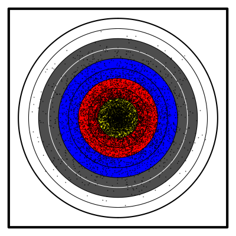

    From those many arrows, Archie has determined an accurate probability distribution (of the points scored by an arrow).

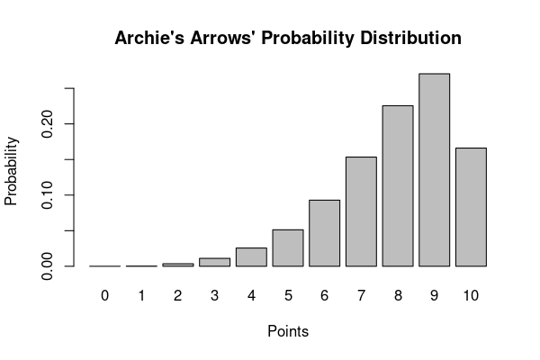

    Thus, Archie can determine her population mean and population standard deviation.
    $$\mu=7.93$$
    $$\sigma=1.66$$

## Sampling distribution

    Each day, Archie shoots 108 arrows ($n=108$) and determines that day’s total score. A total of 1080 would be a perfect day. We can treat each day’s total as a random variable with its own probability distribution: a [sampling distribution](https://en.wikipedia.org/wiki/Sampling_distribution). We wish to characterize this sampling distribution. From the [central limit theorem](https://en.wikipedia.org/wiki/Central_limit_theorem), we know the sampling distribution is approximately normal; however, we need to calculate the parameters.

### Expected total (mean of sampling distribution)

    The expected total is the product of the sample size and the population mean.
    $$\text{expected total} = n\mu$$

    “Expected total” is a misnomer. It is not necessarily likely, or even possible, for a total to equal the expected total. However, if Archie repeatedly shot 108 arrows, we expect the totals to have a mean equal to the expected total. So, maybe “average of totals” would be better terminology.

    This expected total is the average of the sampling distribution.

    Calculate the expected total:

    (Round to the hundredths place)

### Standard error (standard deviation of sampling distribution)

    The standard error of a total is the product of the population standard deviation and the square root of the sample size.
    $$\text{standard error of total} = \sigma \sqrt{n}$$
    This standard error is the standard deviation of the sampling distribution.

    Calculate the standard error:

    (Round to the hundredths place)

## Sample

    Today, Archie’s total score is 896 points ($\sum x = 896$).

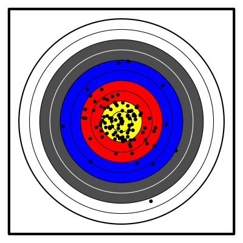

### Standard score

    Archie would like to know how well she did today. She wants you to calculate a standard score (a $z$ score). To calculate the standard score of a sample total, you can use the following formula.
    $$z = \frac{\sum x - n\mu}{\sigma\sqrt{n}}$$

    Calculate the standard score:

    (Round to the hundredths place)

### Cumulative probability (percentile rank)

    Archie would like to know the probability that tomorrow she shoots worse than today. To estimate this, report the cumulative probability associated with the standard score you calculated. This can be done with a [$z$ table](https://en.wikipedia.org/wiki/Standard_normal_table#Conversion), `pnorm` function in R, `NORM.DIST` function in a spreadsheet, or with other standard normal tools.

    Calculate $P(Z\leq z)$, the cumulative probability:

    (Round to the ten-thousandths place)

### Rating

    Archie would like a rating for her day’s performance. You decide to use the following scale and that if $z$ is on a boundary, Archie will be given the higher rating.

    | $z$ interval | rating |
    | --- | --- |
    | $-\infty$ to -1.5 | F |
    | -1.5 to -0.5 | D |
    | -0.5 to 0.5 | C |
    | 0.5 to 1.5 | B |
    | 1.5 to $\infty$ | A |

    Determine Archie’s rating: A / B / C / D / F

#### Question

84. A farm produces 4 types of fruit: coconuts, lemons, mangos, and oranges. The fruits’ masses have population parameters dependent on the type of fruit. (All values are in grams.)

    | _ Type of fruit _ | _ Population mean ($\mu$) _ | _ Population standard deviation ($\sigma$) _ |
    | --- | --- | --- |
    | coconuts | 673 | 59 |
    | lemons | 129 | 15 |
    | mangos | 179 | 18 |
    | oranges | 223 | 15 |

    A sample of each type is weighed. The results are shown below.

    | _ Type of fruit _ | _ Sample size ($n$) _ | _ Sample mean ($\bar{x}$) _ |
    | --- | --- | --- |
    | coconut | 144 | 675.1 |
    | lemon | 49 | 132 |
    | mango | 121 | 177.4 |
    | orange | 100 | 224 |

    The population parameters and sample statistics can be downloaded as a csv.

    For each sample, determine the mean’s standard score and the mean’s [cumulative probability](https://en.wikipedia.org/wiki/Cumulative_distribution_function) by assuming the requirements for the [central limit theorem](https://en.wikipedia.org/wiki/Central_limit_theorem) are met. Then determine which sample mean is most unusually large, most unusually small, most typically sized, and most unusually sized.

    The standard score of a sample mean:
    $$z = \frac{\bar{x}-\mu}{\sigma/\sqrt{n}}$$
    Some people prefer to call this denominator [the standard error](https://en.wikipedia.org/wiki/Standard_error).
    $$\text{standard error of mean} = \text{SEM} = \frac{\sigma}{\sqrt{n}}$$
    So the standard score ($z$-score) of a sample mean can also be expressed as
    $$z = \frac{\bar{x}-\mu}{\text{SEM}}$$
    1. Calculate a $z$-score for the coconut sample mean. (Round to the nearest hundredth.)
    2. What proportion of coconut samples of size $n=144$ have a smaller mean than the coconut sample?
    3. Calculate a $z$-score for the lemon sample mean. (Round to the nearest hundredth.)
    4. What proportion of lemon samples of size $n=49$ have a smaller mean than the lemon sample?
    5. Calculate a $z$-score for the mango sample mean. (Round to the nearest hundredth.)
    6. What proportion of mango samples of size $n=121$ have a smaller mean than the mango sample?
    7. Calculate a $z$-score for the orange sample mean. (Round to the nearest hundredth.)
    8. What proportion of orange samples of size $n=100$ have a smaller mean than the orange sample?
    9. The coconut sample mean is most unusually large. / The lemon sample mean is most unusually large. / The mango sample mean is most unusually large. / The orange sample mean is most unusually large.
    10. The coconut sample mean is most unusually small. / The lemon sample mean is most unusually small. / The mango sample mean is most unusually small. / The orange sample mean is most unusually small.
    11. The coconut sample mean is most typically sized. / The lemon sample mean is most typically sized. / The mango sample mean is most typically sized. / The orange sample mean is most typically sized.
    12. The coconut sample mean is most unusually sized. / The lemon sample mean is most unusually sized. / The mango sample mean is most unusually sized. / The orange sample mean is most unusually sized.

#### Question

85. The continuous random variable $X$ follows the distribution shown by the density curve and spinner below. It has a mean of $\mu_{X}=48.51$ and standard deviation of $\sigma_{X}=8.64$.

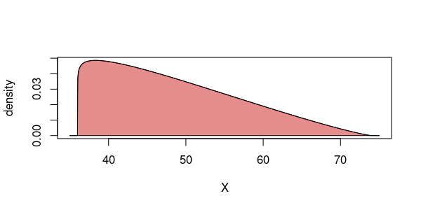

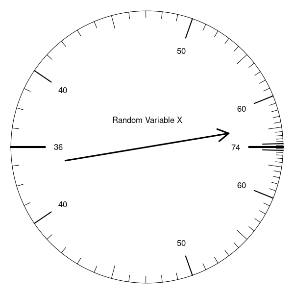

    That spinner ($X$) will be fairly spun 729 times, and the **sample mean** of the spins will be recorded. Determine the probability that the random sample mean is less than 48.03.
    $$P\left(\bar{X}<48.03\right) ~=~ \,?$$

    Please approximate the random mean as a normal distribution with parameters suggested by the central limit theorem.

#### Question

86. The continuous random variable $X$ follows the distribution shown by the density curve and spinner below. It has a mean of $\mu_{X}=90.1$ and standard deviation of $\sigma_{X}=2.98$.

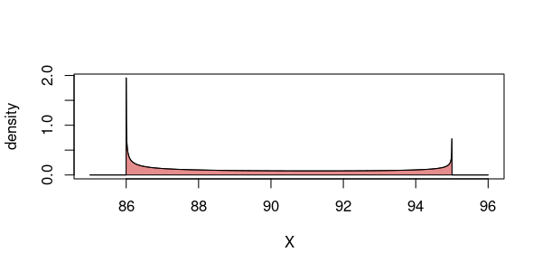

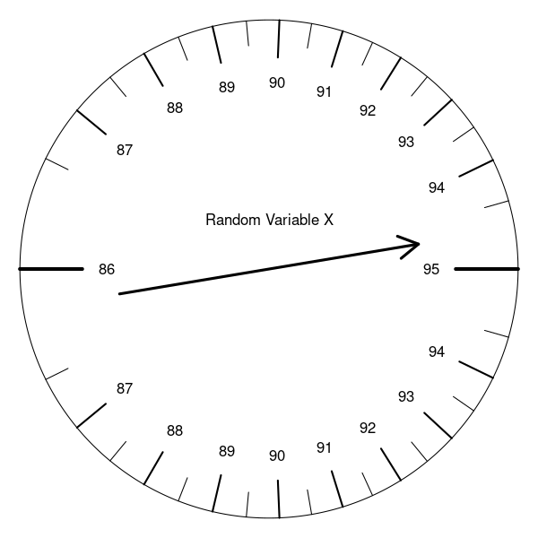

    That spinner ($X$) will be fairly spun 93 times, and the **sample mean** of the spins will be recorded. Determine the probability that the random sample mean is more than 90.49.
    $$P\left(\bar{X}>90.49\right) ~=~ \,?$$

    Please approximate the random mean as a normal distribution with parameters suggested by the central limit theorem.

#### Question

87. The continuous random variable $X$ follows the distribution shown by the density curve and spinner below. It has a mean of $\mu_{X}=34.84$ and standard deviation of $\sigma_{X}=4.04$.

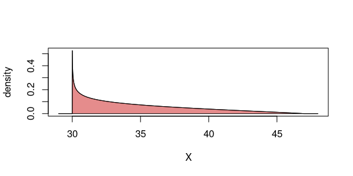

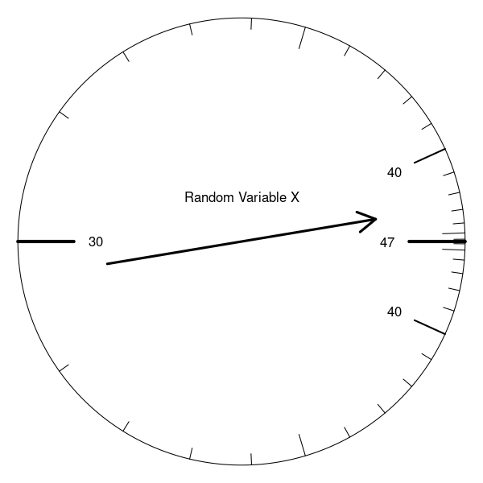

    That spinner ($X$) will be fairly spun 138 times, and the **sample mean** of the spins will be recorded. Determine the probability that the random sample mean is within $0.34$ units from $\mu_{\bar{X}}$.
    $$P\left(\left|\bar{X}-\mu_{\bar{X}}\right|<0.34\right) ~=~ \,?$$

    Please approximate the random mean as a normal distribution with parameters suggested by the central limit theorem.

#### Question

88. The continuous random variable $X$ follows the distribution shown by the density curve and spinner below. It has a mean of $\mu_{X}=49.57$ and standard deviation of $\sigma_{X}=1.87$.

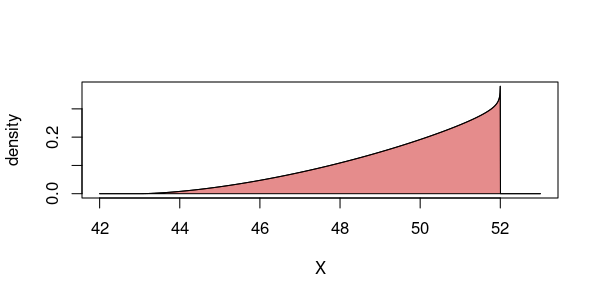

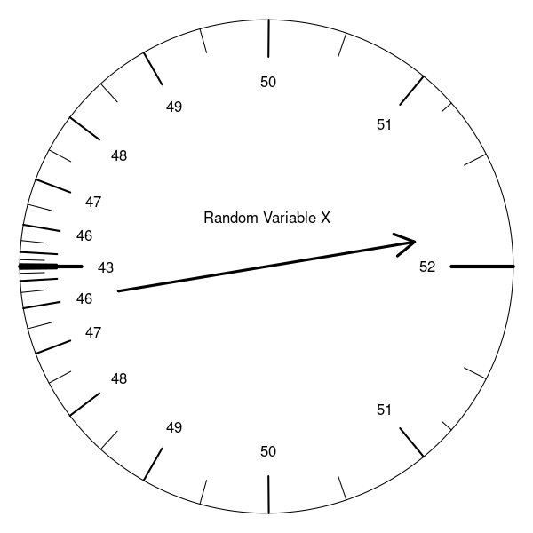

    That spinner ($X$) will be fairly spun 79 times, and the **sample mean** of the spins will be recorded. Determine the probability that the random sample mean is farther than $0.24$ units from $\mu_{\bar{X}}$.
    $$P\left(\left|\bar{X}-\mu_{\bar{X}}\right|>0.24\right) ~=~ \,?$$

    Please approximate the random mean as a normal distribution with parameters suggested by the central limit theorem.

#### Question

89. A fair 8-sided die (with sides numbered 1 through 8) will be rolled 64 times, and the sum (total) of those rolls will be recorded. What is the probability that the **sum** is less than 305.5?
    $$P\left(\sum X < 305.5\right) ~=~ ?$$

    To help you along, I will calculate the mean and standard deviation of **single** rolls. The formulas for an $N$-sided die can be derived from the formulas for [discrete uniform distribution](https://en.wikipedia.org/wiki/Discrete_uniform_distribution).
    $$\mu_{ X} ~=~ \frac{N+1}{2} ~=~ \frac{8+1}{2} ~=~ 4.5$$
    $$\sigma_{ X} ~=~ \sqrt{\frac{N^2-1}{12}} ~=~ \sqrt{\frac{8^2-1}{12}} ~=~ 2.2912878$$

    Please use a normal approximation based on the central limit theorem.

#### Question

90. The continuous random variable $X$ follows the distribution shown by the density curve and spinner below. It has a mean of $\mu_{X}=83.68$ and standard deviation of $\sigma_{X}=5.73$.

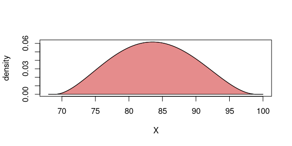

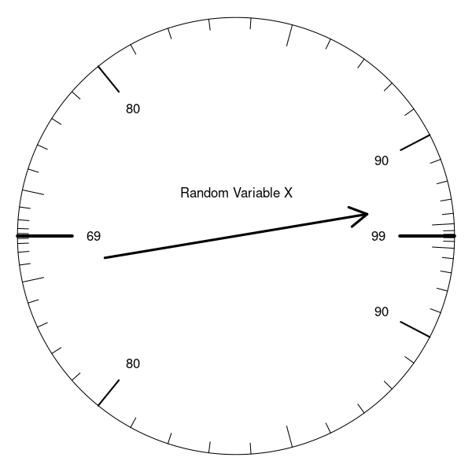

    That spinner ($X$) will be fairly spun 184 times, and the **total** of the spins will be recorded. Determine the probability that the random total is more than 15400.
    $$P\left(\sum{X}>15400\right) ~=~ \,?$$

    Please approximate the random total as a normal distribution with parameters suggested by the central limit theorem.

#### Question

91. The continuous random variable $X$ follows the distribution shown by the density curve and spinner below. It has a mean of $\mu_{X}=61.48$ and standard deviation of $\sigma_{X}=7.31$.

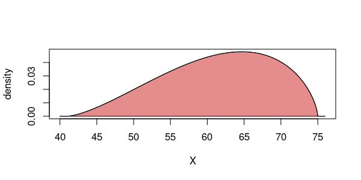

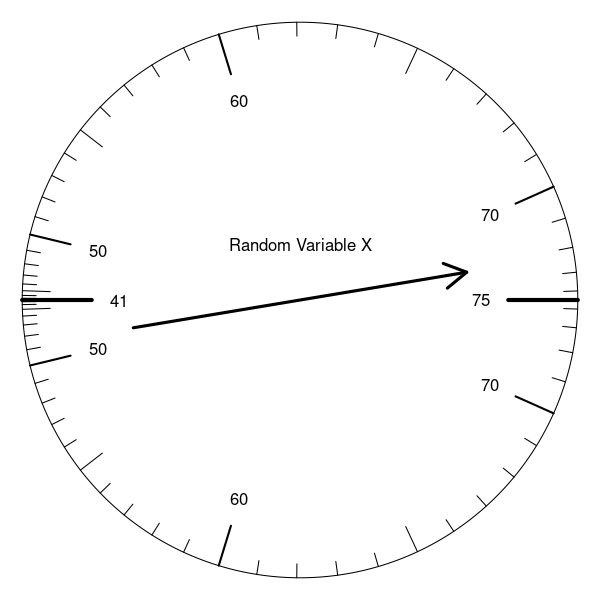

    That spinner ($X$) will be fairly spun 146 times, and the **total** of the spins will be recorded. Determine the probability that the random total is within 53.92 units from $\mu_{\sum X}$.
    $$P\left(\left|\sum{X}-\mu_{\sum X}\right|<53.92\right) ~=~ \,?$$

    Please approximate the random total as a normal distribution with parameters suggested by the central limit theorem.

#### Question

92. The continuous random variable $X$ follows the distribution shown by the density curve and spinner below. It has a mean of $\mu_{X}=35.02$ and standard deviation of $\sigma_{X}=3.38$.

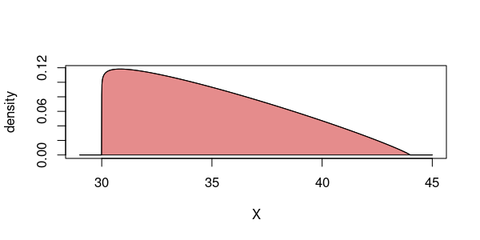

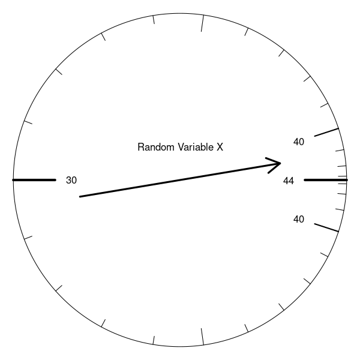

    That spinner ($X$) will be fairly spun 75 times, and the **total** of the spins will be recorded. Determine the probability that the random total is farther than 33.5 units from $\mu_{\sum X}$.
    $$P\left(\left|\sum{X}-\mu_{\sum X}\right|>33.5\right) ~=~ \,?$$

    Please approximate the random total as a normal distribution with parameters suggested by the central limit theorem.

#### Question

93. In some game, each trial has a $p = 0.15$ probability of success. A player will attempt 190 trials. What is the probability that the number of successes is less than 27.5?

#### Question

94. In some game, each trial has a $p = 0.5$ probability of success. A player will attempt 90 trials. What is the probability that the number of successes is more than 52.5?

#### Question

95. In some game, each trial has a $p = 0.48$ probability of success. A player will attempt 195 trials. What is the probability that the number of successes is between 91.5 and 100.5?

#### Question

96. In some game, each trial has a $p = 0.62$ probability of success. A player will attempt 98 trials. What is the probability that the proportion of successes is less than 0.6276?

#### Question

97. In some game, each trial has a $p = 0.92$ probability of success. A player will attempt 135 trials. What is the probability that the proportion of successes is more than 0.9444?

#### Question

98. In some game, each trial has a $p = 0.7$ probability of success. A player will attempt 191 trials. What is the probability that the proportion of successes is between 0.7199 and 0.7356?

#### Question

99. The following questions use $Z$ to refer to the [standard normal](https://en.wikipedia.org/wiki/Standard_normal_table) variable. You will determine some probabilities and some boundaries.
    1. Determine $z$ such that $P(Z<z)=0.0708$
    2. Determine $P(-1.44<Z<1.44)$
    3. Determine $P(Z<0.26)$
    4. Determine $z$ such that $P(Z>z)=0.4364$
    5. Determine $P(Z>0.47)$

#### Question

100. Let random variable $X$ be normally distributed with mean $\mu=30$ and standard deviation $\sigma=9$.
     1. Determine $P(X>29.1)$
     2. Determine $x$ such that $P(X>x)=0.9641$
     3. Determine $P(28.2<X<31.8)$
     4. Determine $x$ such that $P(X<x)=0.4207$
     5. Determine $P(X<21.9)$

#### Question

### Population

101. Random variable $X$ has mean $\mu=55$ and standard deviation $\sigma=4$.

### Interval of typical measurements

     Let the interval of typical measurements be defined as having lower bound $\mu-2\sigma$ and upper bound $\mu+2\sigma$.
     $$\text{interval of typical measurements} = (\mu-2\sigma, \, \mu+2\sigma)$$

     Calculate the lower bound of the interval of typical measurements.

     Calculate the upper bound of the interval of typical measurements.

### Interval of typical totals

     Let the interval of typical totals be defined as having lower bound $n\mu-2\sigma\sqrt{n}$ and upper bound $n\mu+2\sigma\sqrt{n}$.
     $$\text{interval of typical totals} = \left(n\mu-2\sigma\sqrt{n}, \, n\mu+2\sigma\sqrt{n}\right)$$

     For the listed values of $n$, determine the bounds.

     | $n$ | _ lower bound of typical totals _ | _ upper bound of typical totals _ |
     | --- | --- | --- |
     | 25 |  |  |
     | 100 |  |  |
     | 400 |  |  |

### Interval of typical averages

     Let the interval of typical averages be defined as having lower bound $\mu-\frac{2\sigma}{\sqrt{n}}$ and upper bound $\mu+\frac{2\sigma}{\sqrt{n}}$.

     $$\text{interval of typical averages} = \left(\mu-\frac{2\sigma}{\sqrt{n}}, \, \mu+\frac{2\sigma}{\sqrt{n}}\right)$$
     For the listed values of $n$, determine the bounds.

     | $n$ | _ lower bound of typical averages _ | _ upper bound of typical averages _ |
     | --- | --- | --- |
     | 25 |  |  |
     | 100 |  |  |
     | 400 |  |  |

#### Question

### Population

102. Random variable $X$ follows a [Bernoulli distribution](https://en.wikipedia.org/wiki/Bernoulli_distribution) with $p=0.4$. In this context, each spin is often called a trial. A “0” is a “fail” and a “1” is a “success”.

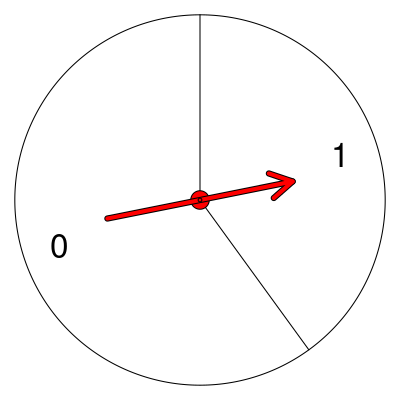

     The average of a Bernoulli random variable is equal to $p$.
     $$\mu=p$$
     Determine $\mu$.

     The standard deviation of a Bernoulli random variable is equal to $\sqrt{p(1-p)}$.
     $$\sigma = \sqrt{p(1-p)}$$
     Determine $\sigma$. (Round to thousandths place.)

### Interval of typical success totals

     The [binomial distribution](https://en.wikipedia.org/wiki/Binomial_distribution) predicts how many successes there will be for a given number of trials. Let the interval of typical successes be defined as having lower bound $np-2\sqrt{np(1-p)}$ and upper bound $np+2\sqrt{np(1-p)}$.
     $$\text{interval of typical successes} = \left(np-2\sqrt{np(1-p)}, \, np+2\sqrt{np(1-p)}\right)$$

     For the listed values of $n$, determine the bounds. (Round to nearest integer.)

     | $n$ | _ lower bound of typical successes _ | _ upper bound of typical successes _ |
     | --- | --- | --- |
     | 25 |  |  |
     | 100 |  |  |
     | 400 |  |  |

### Interval of typical proportions

     Let the interval of typical proportions be defined as having lower bound $p-2\sqrt{\frac{p(1-p)}{n}}$ and upper bound $p+2\sqrt{\frac{p(1-p)}{n}}$.

     $$\text{interval of typical proportions} = \left(p-2\sqrt{\frac{p(1-p)}{n}}, \, p+2\sqrt{\frac{p(1-p)}{n}}\right)$$
     For the listed values of $n$, determine the bounds. (Round to nearest hundredth.)

     | $n$ | _ lower bound of typical proportions _ | _ upper bound of typical proportions _ |
     | --- | --- | --- |
     | 25 |  |  |
     | 100 |  |  |
     | 400 |  |  |

#### Question

103. A farm produces 4 types of fruit: mangos, bananas, oranges, and plums. The fruits’ masses have population parameters dependent on the type of fruit. (All values are in grams.)

     | _ Type of fruit _ | _ Population mean ($\mu$) _ | _ Population standard deviation ($\sigma$) _ |
     | --- | --- | --- |
     | mangos | 219 | 19 |
     | bananas | 153 | 10 |
     | oranges | 191 | 24 |
     | plums | 64 | 6 |

     A sample of each type is weighed. The results are shown below.

     | _ Type of fruit _ | _ Sample size ($n$) _ | _ Sample mean ($\bar{x}$) _ |
     | --- | --- | --- |
     | mango | 81 | 221.6 |
     | banana | 121 | 152.3 |
     | orange | 100 | 188.6 |
     | plum | 144 | 64.73 |

     The population parameters and sample statistics can be downloaded as a csv.

     For each sample, determine the mean’s standard score and the mean’s [cumulative probability](https://en.wikipedia.org/wiki/Cumulative_distribution_function) by assuming the requirements for the [central limit theorem](https://en.wikipedia.org/wiki/Central_limit_theorem) are met. Then determine which sample mean is most unusually large, most unusually small, most typically sized, and most unusually sized.

     The standard score of a sample mean:
     $$z = \frac{\bar{x}-\mu}{\sigma/\sqrt{n}}$$
     Some people prefer to call this denominator [the standard error](https://en.wikipedia.org/wiki/Standard_error).
     $$\text{standard error of mean} = \text{SEM} = \frac{\sigma}{\sqrt{n}}$$
     So the standard score ($z$-score) of a sample mean can also be expressed as
     $$z = \frac{\bar{x}-\mu}{\text{SEM}}$$
     1. Calculate a $z$-score for the mango sample mean. (Round to the nearest hundredth.)
     2. What proportion of mango samples of size $n=81$ have a smaller mean than the mango sample?
     3. Calculate a $z$-score for the banana sample mean. (Round to the nearest hundredth.)
     4. What proportion of banana samples of size $n=121$ have a smaller mean than the banana sample?
     5. Calculate a $z$-score for the orange sample mean. (Round to the nearest hundredth.)
     6. What proportion of orange samples of size $n=100$ have a smaller mean than the orange sample?
     7. Calculate a $z$-score for the plum sample mean. (Round to the nearest hundredth.)
     8. What proportion of plum samples of size $n=144$ have a smaller mean than the plum sample?
     9. The mango sample mean is most unusually large. / The banana sample mean is most unusually large. / The orange sample mean is most unusually large. / The plum sample mean is most unusually large.
     10. The mango sample mean is most unusually small. / The banana sample mean is most unusually small. / The orange sample mean is most unusually small. / The plum sample mean is most unusually small.
     11. The mango sample mean is most typically sized. / The banana sample mean is most typically sized. / The orange sample mean is most typically sized. / The plum sample mean is most typically sized.
     12. The mango sample mean is most unusually sized. / The banana sample mean is most unusually sized. / The orange sample mean is most unusually sized. / The plum sample mean is most unusually sized.

#### Question

104. This question provides $\mu$, $\sigma$, $n$, and $\sum x$. You will characterize the sampling distribution, calculate the standard score, determine the percentile rank (expressed as a decimal), and translate the score into a rating (see below).

### Population

     When Archie practices archery, each arrow has the same probability distribution (see [i.i.d](https://en.wikipedia.org/wiki/Independent_and_identically_distributed_random_variables)). This means her skill is constant, there is no [hot-hand effect](https://en.wikipedia.org/wiki/Hot_hand), and there is no [maturity of chances](https://en.wikipedia.org/wiki/Gambler%27s_fallacy).

     Over many months, Archie has shot ten thousand arrows (their positions are shown below as dots).

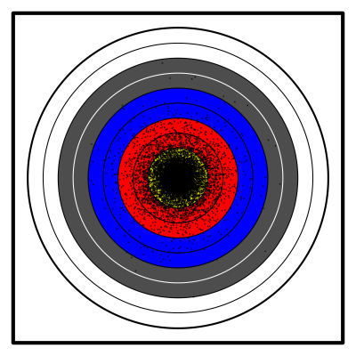

     From those many arrows, Archie has determined an accurate probability distribution (of the points scored by an arrow).

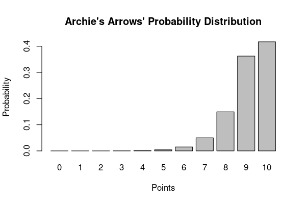

     Thus, Archie can determine her population mean and population standard deviation.
     $$\mu=9.1$$
     $$\sigma=1$$

## Sampling distribution

     Each day, Archie shoots 48 arrows ($n=48$) and determines that day’s total score. A total of 480 would be a perfect day. We can treat each day’s total as a random variable with its own probability distribution: a [sampling distribution](https://en.wikipedia.org/wiki/Sampling_distribution). We wish to characterize this sampling distribution. From the [central limit theorem](https://en.wikipedia.org/wiki/Central_limit_theorem), we know the sampling distribution is approximately normal; however, we need to calculate the parameters.

### Expected total (mean of sampling distribution)

     The expected total is the product of the sample size and the population mean.
     $$\text{expected total} = n\mu$$

     “Expected total” is a misnomer. It is not necessarily likely, or even possible, for a total to equal the expected total. However, if Archie repeatedly shot 48 arrows, we expect the totals to have a mean equal to the expected total. So, maybe “average of totals” would be better terminology.

     This expected total is the average of the sampling distribution.

     Calculate the expected total:

     (Round to the hundredths place)

### Standard error (standard deviation of sampling distribution)

     The standard error of a total is the product of the population standard deviation and the square root of the sample size.
     $$\text{standard error of total} = \sigma \sqrt{n}$$
     This standard error is the standard deviation of the sampling distribution.

     Calculate the standard error:

     (Round to the hundredths place)

## Sample

     Today, Archie’s total score is 442 points ($\sum x = 442$).

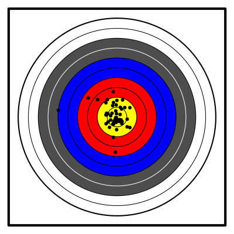

### Standard score

     Archie would like to know how well she did today. She wants you to calculate a standard score (a $z$ score). To calculate the standard score of a sample total, you can use the following formula.
     $$z = \frac{\sum x - n\mu}{\sigma\sqrt{n}}$$

     Calculate the standard score:

     (Round to the hundredths place)

### Cumulative probability (percentile rank)

     Archie would like to know the probability that tomorrow she shoots worse than today. To estimate this, report the cumulative probability associated with the standard score you calculated. This can be done with a [$z$ table](https://en.wikipedia.org/wiki/Standard_normal_table#Conversion), `pnorm` function in R, `NORM.DIST` function in a spreadsheet, or with other standard normal tools.

     Calculate $P(Z\leq z)$, the cumulative probability:

     (Round to the ten-thousandths place)

### Rating

     Archie would like a rating for her day’s performance. You decide to use the following scale and that if $z$ is on a boundary, Archie will be given the higher rating.

     | $z$ interval | rating |
     | --- | --- |
     | $-\infty$ to -1.5 | F |
     | -1.5 to -0.5 | D |
     | -0.5 to 0.5 | C |
     | 0.5 to 1.5 | B |
     | 1.5 to $\infty$ | A |

     Determine Archie’s rating: A / B / C / D / F

#### Question

105. Random variable $X$ is normally distributed with mean $\mu=65$ and standard deviation $\sigma=9$.
     $$X \sim N(65, 9)$$
     1. If $n=100$, determine $P\left(\sum X <6544\right)$
     2. If $n=25$, determine $P\left(\sum X >1594\right)$
     3. If $n=144$, determine $P\left(\overline{X}<63.87\right)$
     4. Determine $P(X>66.9)$
     5. If $n=121$, determine $P\left(\overline{X}>63.53\right)$
     6. Determine $P(X<74.5)$

#### Question

106. In some game, each trial has chance $p=0.43$ of success. In other words, $X$ is a [random Bernoulli variable](https://en.wikipedia.org/wiki/Bernoulli_distribution) with parameter $p=0.43$. To determine the following probabilities, use the de Moivre–Laplace theorem (normal approximation). I have already done the [continuity correction](https://en.wikipedia.org/wiki/Continuity_correction) by setting the boundaries.
     1. If $n=36$, what is the probability that the sample proportion ($\hat{p}$) is more than 0.4583? In other words, if $n=36$, determine $P\left(\overline{X}>0.4583\right)$.In other words, if $n=36$, determine $P\left(\hat{p}>0.4583\right)$.
     2. If $n=81$, what is the probability that the sample proportion ($\hat{p}$) is less than 0.3889? In other words, if $n=81$, determine $P\left(\overline{X}<0.3889\right)$.In other words, if $n=81$, determine $P\left(\hat{p}<0.3889\right)$.
     3. If $n=49$, what is the chance the number of successes is less than 15.5? In other words, if $n=49$, determine $P\left(\sum X <15.5\right)$
     4. If $n=64$, what is the chance the number of successes is more than 23.5? In other words, if $n=64$, determine $P\left(\sum X >23.5\right)$

#### Question

107. 1. If $n=33$, determine $P(T<1.69)$.
     2. If $n=3$, determine $P(T>6.96)$.
     3. If $n=32$, determine $P(|T|<2.74)$.
     4. If $n=19$, determine $P(|T|>2.1)$.
     5. If $n=9$, determine $t$ such that $P(T<t) = 0.995$.
     6. If $n=24$, determine $t$ such that $P(T>t) = 0.01$.
     7. If $n=15$, determine $t$ such that $P(|T|<t) = 0.8$.
     8. If $n=32$, determine $t$ such that $P(|T|>t) = 0.04$.

#### Question

108. A scientist has weighed 49 specimens of a newly discovered organism. Those weights have a *sample mean* of $\bar{x} =19.9$ grams and a sample standard deviation of $s=6.5$ grams. The scientist hopes to construct a 95% [**confidence interval**](https://en.wikipedia.org/wiki/Confidence_interval) of the organism’s *population mean* ($\mu$).

     The scientist will later consult a statistician for a more precise method, but for now she will use a quick method to estimate the 95% confidence interval:
     $$\bar{x}\pm \frac{2s}{\sqrt{n}}$$

     (You can round to nearest 0.1 grams.)
     1. Determine the lower boundary of the confidence interval by using $\bar{x}-\frac{2s}{\sqrt{n}}$.
     2. Determine the upper boundary of the confidence interval by using $\bar{x}+\frac{2s}{\sqrt{n}}$.

#### Question

109. A scientist has grown 170 specimens under novel conditions and found that 12.94% of them survived (in other words $\hat{p}=0.1294$). The scientist hopes to construct a 95% [**confidence interval**](https://en.wikipedia.org/wiki/Confidence_interval) of the survival rate.

     The scientist will later consult a statistician for a more precise method, but for now she will use a quick method to estimate the 95% confidence interval:
     $$\hat{p}\pm 2\sqrt{\frac{\hat{p}(1-\hat{p})}{n}}$$

     (You can round answers to the nearest thousandth.)
     1. Determine the lower boundary of the confidence interval by using $\hat{p}- 2\sqrt{\frac{\hat{p}(1-\hat{p})}{n}}$.
     2. Determine the upper boundary of the confidence interval by using $\hat{p}+ 2\sqrt{\frac{\hat{p}(1-\hat{p})}{n}}$.

#### Question

110. In $n=236$ trials, there were $n_\text{s}=21$ successes, so the sample proportion is $\hat{p}=\frac{21}{236}=0.089$. You are tasked with determining the confidence interval (of the population proportion) with confidence level $\gamma=0.82$.

     To do this, you first determine $z^\star$ such that $P(|Z|<z^\star)=0.82$. Then, evaluate $\hat{p}\pm z^\star\sqrt{\frac{\hat{p}(1-\hat{p})}{n}}$ to determine the boundaries of the confidence interval.

     (You can round answers to the hundredths place.)
     1. Determine the lower boundary of the confidence interval by using $\hat{p}- z^\star\sqrt{\frac{\hat{p}(1-\hat{p})}{n}}$.
     2. Determine the upper boundary of the confidence interval by using $\hat{p}+ z^\star\sqrt{\frac{\hat{p}(1-\hat{p})}{n}}$.

#### Question

111. A population’s mean ($\mu$) is unknown, but its standard deviation is known: $\sigma=28.3$. A sample of size $n=216$ is taken, and the sample mean is calculated: $\bar{x}=89.5$. You are tasked with determining a confidence interval using a given confidence level: $\gamma=0.85$.

     To do this, you need to first determine $z^\star$ such that $P(|Z|<z^\star)=0.85$. Then, the boundaries are determined by evaluating $\bar{x}\pm \frac{z^\star \sigma}{\sqrt{n}}$.

     (You can round $z^\star$ to the nearest hundredth and the boundaries to the nearest tenth.)
     1. Determine the lower boundary of the confidence interval by using $\bar{x}-\frac{z^\star \sigma}{\sqrt{n}}$.
     2. Determine the upper boundary of the confidence interval by using $\bar{x}+\frac{z^\star \sigma}{\sqrt{n}}$.

#### Question

112. A population’s mean ($\mu$) and standard deviation ($\sigma$) are unknown, but the population is approximately normal. A sample of size $n=15$ is taken, and the sample mean is calculated: $\bar{x}=28.6$. The sample standard deviation is also calculated: $s=7.9$. You are tasked with determining a confidence interval using a given confidence level: $\gamma=0.96$.

     To do this, you need to first determine $t^\star$ such that $P(|T|<t^\star)=0.96$. Then, the boundaries are determined by evaluating $\bar{x}\pm \frac{t^\star s}{\sqrt{n}}$.

     (You can round $t^\star$ to the nearest hundredth and the boundaries to the nearest tenth.)
     1. Determine the lower boundary of the confidence interval by using $\bar{x}-\frac{t^\star s}{\sqrt{n}}$.
     2. Determine the upper boundary of the confidence interval by using $\bar{x}+\frac{t^\star s}{\sqrt{n}}$.

#### Question

113. A sample was taken from a population. The measurements are shown below and can be downloaded as a csv.

     ```
     563, 561, 666, 615, 622, 590, 527, 614, 612, 577, 625, 557, 606, 601, 554, 603, 628, 569, 578, 650, 568, 631
     ```

     You are tasked with determining the confidence interval (of the population mean) with the confidence level of $\gamma=0.96$.
     1. Determine $n$, the sample size.
     2. Determine $\bar{x}$, the sample mean.
     3. Determine $s$, the [sample standard deviation](https://en.wikipedia.org/wiki/Standard_deviation#Corrected_sample_standard_deviation) (with [Bessel correction](https://en.wikipedia.org/wiki/Bessel%27s_correction)).
     4. Calculate $\frac{s}{\sqrt{n}}$, the estimated [**standard error**](https://en.wikipedia.org/wiki/Standard_error).
     5. Determine $t^\star$ such that $P(|T|<t^\star)=0.96$. Remember, $\text{df}=n-1$.
     6. Calculate $\frac{t^\star s}{\sqrt{n}}$, the estimated [margin of error](https://en.wikipedia.org/wiki/Margin_of_error).
     7. Calculate $\bar{x}-\frac{t^\star s}{\sqrt{n}}$, the lower boundary of the 96% confidence interval.
     8. Calculate $\bar{x}+\frac{t^\star s}{\sqrt{n}}$, the upper boundary of the 96% confidence interval.

#### Question

114. When Archie shoots archery, she records the horizontal position ($x$) and vertical position ($y$) of every arrow (in millimeters), using the bullseye as the origin.

     From years of shooting, Archie has determined that $X$ and $Y$ are roughly bell-shaped with population standard deviations $\sigma_x = 96$ and $\sigma_y=100$ mm. However, Archie has a new sight, so her current population means ($\mu_x$ and $\mu_y$) are unknown. (She hopes both are zero.)

     Archie wants to get confidence intervals for $\mu_x$ and $\mu_y$, using a sample size $n=36$ and a confidence level $\gamma=0.98$. Whether or not a confidence interval straddles 0 will determine whether Archie adjusts that aspect of her sight.

### Critical value

     Determine the boundary $z^\star$ such that $P(|Z|<z^\star)=0.98$:

### Margins of error.

     The margin of error represents how much variation we expect in sample means.
     $$\text{ME}_x = \frac{z^\star \sigma_x}{\sqrt{n}}$$
     $$\text{ME}_y = \frac{z^\star \sigma_y}{\sqrt{n}}$$
     Calculate $\text{ME}_x$, the margin of error when sampling $\bar{x}$:

     Calculate $\text{ME}_y$, the margin of error for sampling $\bar{y}$:

### Sample

     Archie shoots $n=36$ arrows.

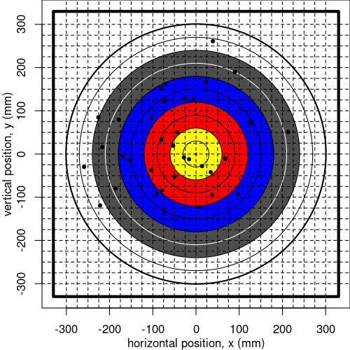

     The exact positions can be downloaded as a csv.

### Sample means

     Calculate $\bar{x}$, the horizontal sample mean: Calculate $\bar{y}$, the vertical sample mean:

### Confidence intervals

     Calculate the 98% confidence interval of $\mu_x$ by using $\bar{x}\pm\text{ME}_x$.

     Calculate the lower boundary:

     Calculate the upper boundary:

     Calculate the 98% confidence interval of $\mu_y$ by using $\bar{y}\pm\text{ME}_y$.

     Calculate the lower boundary:

     Calculate the upper boundary:

### Inference

     If a confidence interval straddles 0, Archie will leave that aspect alone. If a confidence interval does not straddle 0, Archie will adjust that aspect on the sight.

     Does Archie adjust the horizontal aspect of her sight? Yes / No

     Does Archie adjust the vertical aspect of her sight? Yes / No

#### Question

115. A basketball player has decided to estimate her probability to score a [freethrow](https://en.wikipedia.org/wiki/Free_throw). To do this, she shoots freethrows. If she scores, she records a “1”. If she misses, she records a “0”.

     The results are shown below and can be downloaded as a csv.

     ```
     1, 0, 1, 1, 1, 1, 1, 1, 0, 1, 1, 0, 1, 1, 1, 1, 1, 1, 1, 1, 1, 0, 0, 1, 1, 0, 1, 1, 1, 0, 1, 1, 1, 1, 1, 1, 1, 0, 1, 0, 0, 1, 1, 1, 1, 1, 1, 1, 1, 0, 0, 0, 0, 1, 0, 1, 0, 1, 1, 1, 1, 1, 1, 1, 1, 1, 0, 1, 0, 1, 1, 1, 0, 1, 1, 1, 1, 0, 1, 1, 1, 1, 1, 1, 1, 1, 1, 1, 0, 1, 1, 1, 1, 1, 1, 0, 1, 1, 1, 1, 1, 0, 0, 0, 1, 1, 1, 1, 0, 0, 1, 0, 0, 0, 1, 1, 1, 0, 1, 1, 1, 0, 1, 1, 1, 1, 1, 1, 1, 0, 1, 1, 1, 1, 1, 1, 1, 1, 1, 1
     ```

     You are asked to determine a [confidence interval](https://en.wikipedia.org/wiki/Binomial_proportion_confidence_interval) using a given confidence level: $\gamma=0.96$. To do this, you [determine](https://en.wikipedia.org/wiki/Confidence_interval#Basic_steps) $z^\star$ such that $P(|Z|<z^\star)=0.96$. You also calculate the sample size and sample proportion. Then, you use the following formulas:
     $$\text{LB} = \hat{p}-z^\star \sqrt{\frac{\hat{p}(1-\hat{p})}{n}}$$
     $$\text{UB} = \hat{p}+z^\star \sqrt{\frac{\hat{p}(1-\hat{p})}{n}}$$
     1. Determine the lower boundary of the confidence interval
     2. Determine the upper boundary of the confidence interval

#### Question

116. We can approximate a 95% confidence interval (where the 95% refers to the confidence level: how frequently these intervals straddle the population mean) by using $\bar{x}\pm \frac{2 s}{\sqrt{n}}$.
     $$\text{lower boundary} = \bar{x}-\frac{2s}{\sqrt{n}}$$
     $$\text{upper boundary} = \bar{x}+\frac{2s}{\sqrt{n}}$$
     where $\bar{x}$ is the sample mean, $s$ is the sample standard deviation, and $n$ is the sample size. The 2 comes from the fact that 95% of normal measurements land within 2 standard deviations from the mean.

     The quantity that we subtract from or add to the sample mean is called **the margin of error**.
     $$\text{margin of error} = \frac{2s}{\sqrt{n}}$$

     When using a confidence level of 0.95, knowing $s$ will be approximately 65, and wanting the margin of error to be approximately 2.2, how large does the sample size need to be?

     You can round your answer to two significant digits.

#### Question

117. We can approximate a 95% confidence interval of a **proportion** (where the 95% refers to how frequently these intervals straddle the population proportion) by using $\hat{p} \pm \frac{2 \sqrt{\hat{p}(1-\hat{p})}}{\sqrt{n}}$.
     $$\text{lower boundary} = \hat{p} - \frac{2 \sqrt{\hat{p}(1-\hat{p})}}{\sqrt{n}}$$
     $$\text{upper boundary} = \hat{p} + \frac{2 \sqrt{\hat{p}(1-\hat{p})}}{\sqrt{n}}$$
     where $\hat{p}$ is the sample proportion and $n$ is the sample size. The 2 comes from the fact that 95% of normal measurements land within 2 standard deviations from the mean.

     The quantity that we subtract from or add to the sample proportion is called **the margin of error**.
     $$\text{margin of error} = \frac{2 \sqrt{\hat{p}(1-\hat{p})}}{\sqrt{n}}$$

     If we know $\hat{p}$ will be approximately 0.57, and we want the margin of error to be approximately 0.0043, then how large does the sample size need to be?

     You can round your answer to two significant digits.

#### Question

118. A scientist is investigating whether a chemical may effect the growth of an organism. Under the control conditions (no chemical), the organism grows to a mean mass of $\mu_0 = 35.1$ grams with a standard deviation of $\sigma_0 =10.6$ grams. These values are known precisely because the organism has been grown under control conditions many many times.

     The scientist has only grown the organism under experimental conditions (with chemical) $n=47$ times. In that sample, the masses have a mean $\bar{x}=32.46$.

     The scientist wonders if this sample mean is significantly different from $\mu_0$. To investigate this, the scientist will determine the [$p$-value](https://en.wikipedia.org/wiki/P-value). The $p$-value represents the probability of getting a sample mean as far (or farther) from $\mu_0$ due to chance alone.
     $$p\text{-value} ~=~ P\left(\big|Z\big| > \frac{\big|\bar{x}-\mu_0\big|}{\sigma_0/\sqrt{n}} \right)$$

     It is common to compare the $p$-value to 0.05.
     - If $p\text{-value} < 0.05$ then “significant”
     - If $p\text{-value} \ge 0.05$ then “not significant”
     1. Determine the $p$-value.
     2. The difference is significant. The chemical seems to alter the growth of the organism. / The difference is not significant. We don’t know whether the chemical alters the growth of the organism.

#### Question

119. A scientist is investigating whether a chemical may effect the survival rate of an organism. Under the control conditions (no chemical), the organism has a survival rate of $p_0=0.5846$. This value is known precisely because the organism has been grown under control conditions many many times.

     The scientist has only grown the organism under experimental conditions (with chemical) $n=65$ times. In that sample, the survival rate is $\hat{p} = 0.7231$.

     The scientist wonders if this survival rate is significantly different from $p_0$. To investigate this, the scientist will determine the $p$-value. The $p$-value represents the probability of getting a sample proportion as far (or farther) from $p_0$ due to chance alone.
     $$p\text{-value} ~=~ P\left(\big|Z\big| > \frac{\big|\hat{p}-p_0\big|}{\sqrt{\frac{p_0(1-p_0)}{n}}} \right)$$

     It is common to compare the $p$-value to 0.05.
     - If $p\text{-value} < 0.05$ then “significant”
     - If $p\text{-value} \ge 0.05$ then “not significant”
     1. Determine the $p$-value.
     2. The difference is significant. The chemical seems to alter the growth of the organism. / The difference is not significant. We don’t know whether the chemical alters the growth of the organism.

#### Question

120. Archie worries the horizontal aspect of her sight may be off. She decides to run a [one-sample t test](https://en.wikipedia.org/wiki/Student's_t-test#Uses) on the $x$ values of her next 50 arrows. She will use a [significance level](https://en.wikipedia.org/wiki/Statistical_significance) of $\alpha=0.05$. If the result has statistical significance, Archie will adjust her sight.

### Result

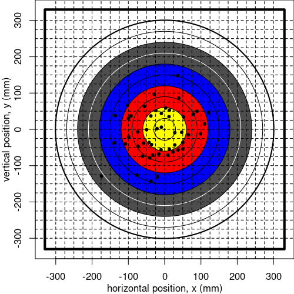

     The horizontal positions are shown below and can be downloaded as a csv.

     ```
     -24, 13, 39, 50, 13, -29, 50, -41, 28, 110, 36, -10, 99, -108, -43, 28, -9, 23, -99, -61, -56, 3, 79, -38, 52, -100, -174, -38, -36, -77, 89, -21, -138, -20, -50, -93, -58, 12, -74, 65, -33, 47, -102, 121, -16, 9, -73, 37, -9, -136
     ```

### Analysis

     To get the $p$-value:
     $$p\text{-value} ~=~ P\left(\big|T\big| > \frac{\big|\bar{x}-\mu_0\big|}{s/\sqrt{n}} \right)$$

     In this situation, the null population mean is zero.
     $$\mu_0=0$$
     In other words, [the null hypothesis](https://en.wikipedia.org/wiki/Exclusion_of_the_null_hypothesis) claims the sight is correct and the difference between $\bar{x}$ and 0 is just due to chance. The [alternative hypothesis](https://en.wikipedia.org/wiki/Alternative_hypothesis) claims the sight needs to be adjusted: the difference between $\bar{x}$ and 0 is partly because the sight is off.

     Determine the $p$-value.

     Archie will adjust her sight if the $p$-value is less than 0.05, because this indicates there is statistical significance. Does Archie adjust her sight? Yes. / No.

#### Question

121. Connie suspects a coin may be unfair when spun on its edge on a table. She decides to record some spins, using “0” for tails and “1” for heads. After those spins, she will run a one-proportion hypothesis test using a significance level $\alpha=0.05$.

     The data is shown below, and can be downloaded as a csv.

     ```
     1, 0, 1, 0, 1, 1, 1, 0, 1, 1, 0, 1, 1, 0, 0, 0, 1, 1, 1, 0, 0, 1, 1, 0, 1, 1, 1, 0, 1, 1, 0, 0, 1, 0, 1, 0, 1, 0, 0, 1, 0, 1, 1, 1, 0, 0, 0, 1, 0, 0, 0, 0, 0, 0, 1, 1, 0, 0, 1, 1, 0, 0, 0, 1, 1, 1, 0, 1, 0, 1, 0, 1, 1, 0, 1, 1, 1, 1, 1, 0, 0, 0, 0, 1, 0, 1, 1, 1, 1, 1, 1, 0, 0, 1, 1, 0, 1, 0, 1, 1, 1, 1, 1, 1, 1, 1, 1, 0, 1, 1, 1, 0, 1, 1, 1, 1, 1, 1, 0, 0, 1, 0, 1, 0, 1, 0, 0, 0, 0, 0, 1, 1, 0, 0, 0, 1, 1, 0, 1, 1, 1, 0, 0, 1, 0, 0, 1, 0, 0, 1, 0, 1, 1, 1, 1, 1, 0, 0, 0, 1, 1, 0, 0, 1, 1, 1, 1, 0, 1, 1, 0, 0, 1, 0, 1, 0, 0
     ```

     The null hypothesis states the coin is fair and any deviation between the sample proportion and 0.5 is merely due to chance and natural variation. Thus, the null population proportion is $p_0=0.5$.

     The alternative hypothesis states the coin is unfair, so the deviation between the sample proportion and 0.5 is at least partly due to the unfairness of the coin.

     The $p$-value will indicate the probability that a fair coin produces a sample mean as extreme (or more extreme) in its deviation from 0.5. An approximate formula, using a normal approximation of the proportion sampling and not using a continuity correction, is given:

     $$p\text{-value} \approx P\left(|Z| > \frac{|\hat{p}-p_0|}{\sqrt{p_0(1-p_0)/n}} \right)$$
     If you want to make a continuity correction, your $p$-value is more accurate (and larger, more conservative).
     $$p\text{-value} \approx P\left(|Z| > \frac{(|\hat{p}-p_0|\cdot n-0.5)/n}{\sqrt{p_0(1-p_0)/n}} \right)$$

     And, if you want to be exactly correct, you need a computer (or a lot of time) to use the [binomial distribution](https://en.wikipedia.org/wiki/Binomial_distribution) formulas.

     $$p\text{-value} = P\left(\left|B(n,p_0)-p_0n\right|\ge \left|n_\text{s}-p_0n\right|\right)$$

     For this problem, you can use any of those three strategies.

     Determine the $p$-value.

     Connie compares the $p$-value to the significance level, $\alpha=0.05$. If the $p$-value is less than 0.05, Connie concludes the coin is unfair. Otherwise, Connie will conclude the coin MIGHT be fair but future measurements may still show the coin is unfair.

     Does Connie conclude the coin is unfair?

     Yes, the sample proportion is significantly far from 0.5, so Connie thinks the coin is unfair. / No, the sample proportion is NOT significantly far from 0.5, so Connie retains the belief that the coin MIGHT be fair.

#### Question

122. A study asked individuals to time a mile run (in seconds). After a month, the same individuals timed another mile run. You are asked to perform a paired-data $t$ test to investigate whether fitness changed.

     | name | x1 | x2 |
     | --- | --- | --- |
     | Charlotte | 654 | 641 |
     | Emani | 751 | 717 |
     | Hudson | 305 | 253 |
     | Jaelani | 305 | 229 |
     | Jayden | 945 | 919 |
     | Julianne | 499 | 557 |
     | Lea | 362 | 285 |
     | Luke | 608 | 672 |
     | Ruby | 485 | 402 |
     | Zaina | 499 | 415 |

     (download as run_times.csv)

     To do this, first determine the list of differences. For each individual, $i$, determine their difference $d_i$.
     $$d_i = x_{2,i}-x_{1,i}$$

     Then, determine the mean ($\bar{d}$) and standard deviation ($s_d$) of the differences. The $t$ score is then calculated to determine the $p$-value.

     $$p\text{-value} = P\left(|T|>\frac{|\overline{d}-\mu_0|}{s_d/\sqrt{n}}\right)$$
     The null hypothesis predicts there is no change in fitness, so $\mu_0=0$. The alternative hypothesis predicts a change in fitness. The degree of freedom is one less than the number of individuals.

     Calculate the $p$-value.

     Using a significance level of $\alpha=0.05$, is there a significant change in run times?

     Yes / No

#### Question

123. A doctor runs a [controlled experiment](https://en.wikipedia.org/wiki/Randomized_controlled_trial). The participants are randomly assigned to two groups: control and treatment. The participants in the control group are given a [placebo](https://en.wikipedia.org/wiki/Placebo-controlled_study). The participants in the treatment group are given a drug.

     After a month, each participant’s triglyceride level (in mg/dL) is measured. Those measurements are shown below. They can also be downloaded as a csv.

     ```
     ## Control: 262.8, 276.4, 243, 237.9, 191.4, 264.4, 202.7, 235.1, 299.3, 300.3, 243.3, 316.9, 249, 332.3, 243.9, 222.5, 203.5, 290.9, 263.4, 271, 212.5
     ##
     ## Treatment: 372.5, 247.7, 278.5, 279.2, 313.1, 242.6, 235.5, 259.4, 270.9, 208.1, 219.2, 245.3, 271.1, 267.7, 338.5, 310.1, 291.8, 243.6, 289.1, 294.4, 289.9, 285.8
     ```

     You are asked to perform a two-tail [two-sample Welch’s $t$ test](https://en.wikipedia.org/wiki/Welch%27s_t-test) to determine whether there is a significant difference of means in the two samples.

     To do this by hand, you would first determine the absolute $t$ score as defined here.
     $$|t| = \frac{|\overline{x}_1-\overline{x}_2|}{\sqrt{\frac{s_1^2}{n_1}+\frac{s_2^2}{n_2}}}$$
     You’d also need to calculate the degrees of freedom.

     $$\text{df} = \frac{\left(\frac{s_1^2}{n_1}+\frac{s_2^2}{n_2}\right)^2}{\frac{s_1^4}{n_1^2(n_1-1)}+\frac{s_2^4}{n_2^2(n_2-1)}}$$
     And then, the $p$-value:

     $$p\text{-value} = P\left(|T|>|t|\right)$$

     However, this problem is easy when using a spreadsheet or R, so I would recommend using one of those tools.

     In a spreadsheet, you can use [`T.TEST`](https://wiki.openoffice.org/wiki/Documentation/How_Tos/Calc:_TTEST_function) with mode=2 for a two-tail test and type=3 for Welch’s test.

     In R, you can use [`t.test`](https://www.rdocumentation.org/packages/stats/versions/3.6.2/topics/t.test) with the default settings.

     Determine the $p$-value.

     Is the difference of means significant (using a significance level of 0.05)?

     Yes, the drug causes a difference in average triglyceride level. / No, we don’t know whether the drug causes a difference.

#### Question

124. A doctor runs a [controlled experiment](https://en.wikipedia.org/wiki/Randomized_controlled_trial). The sick patients are randomly assigned to two groups: control and treatment. The patients in the control group are given a [placebo](https://en.wikipedia.org/wiki/Placebo-controlled_study). The patients in the treatment group are given a drug.

     After a month, each patient was checked for whether they recovered from the sickness. A “0” means no recovery while a “1” means recovery. This data can also be downloaded as a csv.

     ```
     ## Control: 1, 1, 0, 1, 1, 1, 1, 0, 1, 1, 0, 1, 0, 0, 1, 0, 1, 0, 1, 1, 1, 1, 1, 0, 1, 0, 1, 0, 1, 1, 0, 1, 1, 1, 1, 1, 1, 1, 1, 0, 0, 0, 1, 0, 1, 1, 1, 1, 0, 1, 1, 0, 1, 0, 0, 1, 1, 1, 1, 1, 1, 1, 1, 1, 0, 1, 0, 1, 0, 1, 1, 0, 1, 1, 1, 1
     ##
     ## Treatment: 0, 0, 0, 0, 0, 0, 1, 1, 1, 1, 1, 1, 0, 1, 0, 1, 1, 0, 0, 1, 1, 1, 0, 1, 1, 0, 0, 1, 1, 1, 1, 0, 0, 1, 1, 0, 0, 0, 0, 1, 1, 0, 1, 1, 1, 1, 0, 1, 0, 1, 1, 0, 1, 0, 1, 0, 0
     ```

     You are asked to perform a two-tailed [two-proportion test](https://en.wikipedia.org/wiki/Test_statistic#Common_test_statistics). You can do a two-proportions $z$ test (which is equivalent to a 2x2 $\chi^2$ test [[chi squared test](https://en.wikipedia.org/wiki/Chi-squared_test)]). You will get credit whether or not you apply a continuity correction, but please pool data for the standard error estimation.

     Just for completeness, you would also get credit for using [Fisher’s exact test](https://en.wikipedia.org/wiki/Fisher%27s_exact_test).

     Determine the $p$-value.

     Is the difference of means significant (using a significance level of 0.05)?

     Yes, the drug causes a difference in recovery. / No, we don’t know whether the drug causes a difference.

#### Question

125. An automatic bottle filler is supposed to average 300.00 ml of fluid in each bottle. You sampled some random bottles, recording their volumes:

     ```
     298.19, 298.05, 299.35, 297.07, 297.82
     ```

     Download data.

     You are asked to determine a 95% confidence interval, calculate an appropriate $p$-value (using two-tail $t$ test), and state whether the filler needs adjustment using a significance level of 0.05.

     Determine the lower boundary of the confidence interval.

     Determine the upper boundary of the confidence interval.

     Determine the $p$-value.

     Does the filler need adjustment?

     Yes / No

#### Question

126. A scratch-off lottery has a stated chance of 0.63 to win. You sampled some tickets, marking a win as “1” and a loss as “0”.

     ```
     1, 1, 1, 0, 1, 1, 1, 1, 1, 0, 1, 1, 1, 1, 1, 1, 1, 1, 1, 1,
     1, 0, 0, 1, 1, 0, 1, 1, 1, 1, 1, 1, 1, 1, 1, 1, 1, 0, 1, 1,
     1, 1, 0, 0, 1, 1, 0, 1, 0, 1, 1, 1, 1, 1, 0, 1, 1, 1, 0, 1,
     1, 0, 1, 1
     ```

     Download data.

     Please determine a 95% confidence interval, calculate an appropriate $p$-value, and state whether the sample proportion is significantly different than the stated chance (using a significance level of 0.05).

     For the confidence interval, you can use a normal approximation interval, a Wilson score interval, a Wilson score interval with continuity correction, or the exact Clopper-Pearson interval ([see descriptions here](https://en.wikipedia.org/wiki/Binomial_proportion_confidence_interval)).

     For the $p$-value, you can use similarly use a $z$ test, a $\chi^2$ test (with or without continuity correction), or an exact test.

     Determine the lower boundary of the confidence interval.

     Determine the upper boundary of the confidence interval.

     Determine the $p$-value.

     Using a significance level of 0.05, is the sample proportion significantly different from the stated chance?

     Yes / No

#### Question

127. A study asked individuals to time a mile run (in seconds). After a month, the same individuals timed another mile run. You are asked to perform a paired-data $t$ test to investigate whether fitness changed.

     | name | x1 | x2 |
     | --- | --- | --- |
     | Angel | 490 | 441 |
     | Italia | 316 | 252 |
     | June | 337 | 283 |
     | Kalani | 378 | 362 |
     | Luke | 451 | 408 |
     | Maxwell | 623 | 593 |
     | Sarita | 703 | 657 |
     | Serenity | 382 | 390 |
     | Theodore | 279 | 252 |
     | Zara | 431 | 469 |

     (download as run_times.csv)

     Please run a paired $t$-test to check whether there was a significant change in running times.

     Calculate the $p$-value.

     Using a significance level of $\alpha=0.05$, is there a significant change in run times?

     Yes / No

#### Question

128. A doctor runs a [controlled experiment](https://en.wikipedia.org/wiki/Randomized_controlled_trial). The participants are randomly assigned to two groups: control and treatment. The participants in the control group are given a [placebo](https://en.wikipedia.org/wiki/Placebo-controlled_study). The participants in the treatment group are given a drug.

     After a month, each participant’s triglyceride level (in mg/dL) is measured. Those measurements are shown below. They can also be downloaded as a csv.

     ```
     ## Control: 500.1, 519.3, 525.1, 514.5, 498.8, 514, 514.3, 515.3, 525.3, 499.6, 529.8, 518.4, 570.1, 517.4, 520.6, 519.3, 514, 506.9, 520.8, 494.6, 531.4, 486.3, 524.7, 520.9
     ##
     ## Treatment: 562.4, 536, 525, 552.3, 523.9, 533.8, 539, 533.2, 528.6, 529.4, 503.2
     ```

     You are asked to perform a two-tail [two-sample Welch’s $t$ test](https://en.wikipedia.org/wiki/Welch%27s_t-test) to determine whether there is a significant difference of means in the two samples.

     Determine the $p$-value.

     Is the difference of means significant (using a significance level of 0.05)?

     Yes, the drug causes a difference in average triglyceride level. / No, we don’t know whether the drug causes a difference.

#### Question

129. A doctor runs a [controlled experiment](https://en.wikipedia.org/wiki/Randomized_controlled_trial). The sick patients are randomly assigned to two groups: control and treatment. The patients in the control group are given a [placebo](https://en.wikipedia.org/wiki/Placebo-controlled_study). The patients in the treatment group are given a drug.

     After a month, each patient was checked for whether they recovered from the sickness. A “0” means no recovery while a “1” means recovery. This data can also be downloaded as a csv.

     ```
     ## Control: 1, 0, 0, 1, 1, 1, 0, 0, 1, 1, 0, 1, 0, 1, 1, 1, 1, 0, 1, 0, 1, 1, 1, 1, 0, 1, 1, 0, 1, 1, 1, 0, 0, 1, 1, 1, 0, 1, 0, 1, 1, 1, 0, 0, 0, 0, 1, 0, 0, 1, 0, 1, 1, 0, 1, 0, 0, 0, 1, 1, 0, 1, 0, 1, 0, 0, 0, 0, 0, 0, 0, 1, 0, 0, 0, 0, 1, 0, 1
     ##
     ## Treatment: 1, 0, 1, 1, 1, 1, 0, 1, 1, 1, 0, 1, 1, 1, 1, 1, 1, 1, 1, 0, 1, 1, 1, 0, 1, 1, 1, 1, 0, 1, 1, 1, 0, 0, 0, 1, 1, 1, 0, 0, 0, 1, 0, 1, 1, 1, 0, 1, 1, 1, 1, 0, 1, 1, 0, 0, 1, 0, 1, 1, 1, 0, 1, 1, 0, 1, 0, 1, 1, 0, 1, 1
     ```

     You are asked to perform a two-tailed [two-proportion test](https://en.wikipedia.org/wiki/Test_statistic#Common_test_statistics). You can do a two-proportions $z$ test (which is equivalent to a 2x2 $\chi^2$ test [[chi squared test](https://en.wikipedia.org/wiki/Chi-squared_test)]). You will get credit whether or not you apply a continuity correction, but please pool data for the standard error estimation.

     Just for completeness, you can also get credit for using [Fisher’s exact test](https://en.wikipedia.org/wiki/Fisher%27s_exact_test).

     Determine the $p$-value.

     Is the difference of means significant (using a significance level of 0.05)?

     Yes, the drug causes a difference in recovery. / No, we don’t know whether the drug causes a difference.